# Attributes

Instructions to customise the layout of Graphviz nodes, edges, graphs, subgraphs, and clusters.

The table below describes the attributes used by various Graphviz tools. The table gives the name of the attribute, the graph components (node, edge, etc.) which use the attribute and the type of the attribute (strings representing legal values of that type). Where applicable, the table also gives a default value for the attribute, a minimum allowed setting for numeric attributes, and certain restrictions on the use of the attribute.

Note that attribute names are case-sensitive. This is usually true for attribute values as well, unless noted.

All Graphviz attributes are specified by name-value pairs. Thus, to set the `color` of a node `abc`, one would use

```
digraph {
  abc [color = red]
}
```

[Edit in Playground](https://magjac.com/graphviz-visual-editor/?dot=digraph%20%7b%0a%20%20abc%20%5bcolor%20%3d%20red%5d%0a%7d)

Similarly, to set the arrowhead style of an edge `abc -> def`, one would use:

```
digraph {
  abc -> def [arrowhead = diamond]
}
```

[Edit in Playground](https://magjac.com/graphviz-visual-editor/?dot=digraph%20%7b%0a%20%20abc%20-%3e%20def%20%5barrowhead%20%3d%20diamond%5d%0a%7d)

Further details concerning the setting of attributes can be found in the description of the DOT language.

At present, most device-independent units are either inches or points, which we take as 72 points per inch.

**Note:** Some attributes, such as `dir` or `arrowtail`, are ambiguous when used in DOT with an undirected graph since the head and tail of an edge are meaningless. As a convention, the first time an undirected edge appears, the DOT parser will assign the left node as the tail node and the right node as the head. For example, the edge `A -- B` will have tail `A` and head `B`. It is the user's responsibility to handle such edges consistently. If the edge appears later, in the format

```
graph {
  B -- A [taillabel = "tail"]
}
```

[Edit in Playground](https://magjac.com/graphviz-visual-editor/?dot=graph%20%7b%0a%20%20B%20--%20A%20%5btaillabel%20%3d%20%22tail%22%5d%0a%7d)

the drawing will attach the tail label to node `A`. To avoid possible confusion when such attributes are required, the user is encouraged to use a directed graph. If it is important to make the graph appear undirected, this can be done using the `dir`, `arrowtail` or `arrowhead` attributes.

The tools accept standard C representations for `int` and `double` types. For the `bool` type, TRUE values are represented by `true` or `yes` (case-insensitive) and any non-zero integer, and FALSE values by `false` or `no` (case-insensitive) and zero. In addition, there are a variety of specialized types such as `arrowType`, `color`, `point` and `rankdir`. Legal values for these types are given at the end.

The **Used By** column field indicates which graph component(s) the attribute applies to.

In the **Notes** field, an annotation of *write only* indicates that the attribute is used for output, and is not used or read by any of the layout programs.

| Name | Used By | Type | Default | Minimum | Description, notes |
| --- | --- | --- | --- | --- | --- |
| `_background` | Graphs | xdot | `<none>` |  | A string in the `xdot` format specifying an arbitrary background. |
| `area` | Nodes, Clusters | double | `1.0` | `>0` | Indicates the preferred area for a node or empty cluster. patchwork only. |
| `arrowhead` | Edges | arrowType | `normal` |  | Style of arrowhead on the head node of an edge. |
| `arrowsize` | Edges | double | `1.0` | `0.0` | Multiplicative scale factor for arrowheads. |
| `arrowtail` | Edges | arrowType | `normal` |  | Style of arrowhead on the tail node of an edge. |
| `bb` | Clusters, Graphs | rect |  |  | Bounding box of drawing in points. write only. |
| `beautify` | Graphs | bool | `false` |  | Whether to draw leaf nodes uniformly in a circle around the root node in sfdp.. sfdp only. |
| `bgcolor` | Graphs, Clusters | color, colorList | `<none>` |  | Canvas background color. |
| `center` | Graphs | bool | `false` |  | Whether to center the drawing in the output canvas. |
| `charset` | Graphs | string | `"UTF-8"` |  | Character encoding used when interpreting string input as a text label.. |
| `class` | Edges, Nodes, Clusters, Graphs | string | `""` |  | Classnames to attach to the node, edge, graph, or cluster's SVG element. svg only. |
| `cluster` | Clusters, Subgraphs | bool | `false` |  | Whether the subgraph is a cluster. |
| `clusterrank` | Graphs | clusterMode | `local` |  | Mode used for handling clusters. dot only. |
| `color` | Edges, Nodes, Clusters | color, colorList | `black` |  | Basic drawing color for graphics, not text. |
| `colorscheme` | Edges, Nodes, Clusters, Graphs | string | `""` |  | A color scheme namespace: the context for interpreting color names. |
| `comment` | Edges, Nodes, Graphs | string | `""` |  | Comments are inserted into output. |
| `compound` | Graphs | bool | `false` |  | If true, allow edges between clusters. dot only. |
| `concentrate` | Graphs | bool | `false` |  | If true, use edge concentrators. |
| `constraint` | Edges | bool | `true` |  | If false, the edge is not used in ranking the nodes. dot only. |
| `Damping` | Graphs | double | `0.99` | `0.0` | Factor damping force motions.. neato only. |
| `decorate` | Edges | bool | `false` |  | Whether to connect the edge label to the edge with a line. |
| `defaultdist` | Graphs | double | `1+(avg. len)*sqrt(\|V\|)` | `epsilon` | The distance between nodes in separate connected components. neato only. |
| `dim` | Graphs | int | `2` | `2` | Set the number of dimensions used for the layout. neato, fdp, sfdp only. |
| `dimen` | Graphs | int | `2` | `2` | Set the number of dimensions used for rendering. neato, fdp, sfdp only. |
| `dir` | Edges | dirType | `forward` (directed) `none` (undirected) |  | Edge type for drawing arrowheads. |
| `diredgeconstraints` | Graphs | string, bool | `false` |  | Whether to constrain most edges to point downwards. neato only. |
| `distortion` | Nodes | double | `0.0` | `-100.0` | Distortion factor for `shape=polygon`. |
| `dpi` | Graphs | double | `96.0` | `0.0` | Specifies the expected number of pixels per inch on a display device. bitmap output, svg only. |
| `edgehref` | Edges | escString | `""` |  | Synonym for `edgeURL`. map, svg only. |
| `edgetarget` | Edges | escString | `<none>` |  | Browser window to use for the `edgeURL` link. map, svg only. |

[output cut: 146 more lines]

### _background

A string in the `xdot` format specifying an arbitrary background

type: *xdot, default: `<none>`*

During rendering, the canvas is first filled as described in the `bgcolor` attribute.

Then, if `_background` is defined, the graphics operations described in the string are performed on the canvas.

See `xdot` format page for more information.

Render a red square in the background

```
digraph G {
  _background="c 7 -#ff0000 p 4 4 4 36 4 36 36 4 36";
  a -> b
}
```

[Edit in Playground](https://magjac.com/graphviz-visual-editor/?dot=digraph%20G%20%7b%0a%20%20_background%3d%22c%207%20-%23ff0000%20p%204%204%204%2036%204%2036%2036%204%2036%22%3b%0a%20%20a%20-%3e%20b%0a%7d)

*Valid on:*

- Graphs

### area

Indicates the preferred area for a node or empty cluster

type: *double, default: `1.0`, minimum: `>0`*

Example: Australian Coins, area proportional to value

```
graph {
  layout="patchwork"
  node [style=filled]
  "5c"  [area=  5 fillcolor=silver]
  "10c" [area= 10 fillcolor=silver]
  "20c" [area= 20 fillcolor=silver]
  "50c" [area= 50 fillcolor=silver]
  "$1"  [area=100 fillcolor=gold]
  "$2"  [area=200 fillcolor=gold]
}
```

Edit in Playground

*Valid on:*

- Nodes
- Clusters

*Note: patchwork only.*

### arrowhead

Style of arrowhead on the head node of an edge

type: *arrowType, default: `normal`*

This will only appear if the `dir` attribute is `forward` or `both`.

See the limitation.

See also:

- `arrowtail`

*Valid on:*

- Edges

### arrowsize

Multiplicative scale factor for arrowheads

type: *double, default: `1.0`, minimum: `0.0`*

Example

```
digraph {
  quiver -> "0.5" [arrowsize=0.5]
  quiver -> "1"
  quiver -> "2" [arrowsize=2]
  quiver -> "3" [arrowsize=3]
}
```

Edit in Playground

*Valid on:*

- Edges

### arrowtail

Style of arrowhead on the tail node of an edge

type: *arrowType, default: `normal`*

This will only appear if the `dir` attribute is `back` or `both`.

See the limitation.

See also:

- `arrowhead`

*Valid on:*

- Edges

### bb

Bounding box of drawing in points

type: *rect*

*Valid on:*

- Clusters
- Graphs

*Note: write only.*

### beautify

Whether to draw leaf nodes uniformly in a circle around the root node in sfdp.

type: *bool, default: `false`*

Whether to try to draw leaf nodes uniformly on a circle around the root node.

Prior to Graphviz 8.0.1, this is affected by [Issue 2283](https://gitlab.com/graphviz/graphviz/-/issues/2283): rendering one fewer sector than necessary, overlapping the first and last nodes.

Examples:

Beautify

```
digraph G {
    layout="sfdp"
    beautify=true

    N0 -> {N1; N2; N3; N4; N5; N6}
}
```

Edit in Playground

No beautify

```
digraph G {
    layout="sfdp"
    beautify=false

    N0 -> {N1; N2; N3; N4; N5; N6}
}
```

Edit in Playground

*Valid on:*

- Graphs

*Note: sfdp only.*

### bgcolor

Canvas background color

type: *color | colorList, default: `<none>`*

When attached to the root graph, this color is used as the background for entire canvas.

When a cluster attribute, it is used as the initial background for the cluster. If a cluster has a filled `style`, the cluster's `fillcolor` will overlay the background color.

If the value is a `colorList`, a gradient fill is used. By default, this is a linear fill; setting `style=radial` will cause a radial fill. Only two colors are used. If the second color (after a colon) is missing, the default color is used for it. See also the `gradientangle` attribute for setting the gradient angle.

For certain output formats, such as PostScript, no fill is done for the root graph unless `bgcolor` is explicitly set.

For bitmap formats, however, the bits need to be initialized to something, so the canvas is filled with white by default. This means that if the bitmap output is included in some other document, all of the bits within the bitmap's bounding box will be set, overwriting whatever color or graphics were already on the page. If this effect is not desired, and you only want to set bits explicitly assigned in drawing the graph, set `bgcolor="transparent"`.

Example

```
graph {
  bgcolor="lightblue"
  label="Home"
  subgraph cluster_ground_floor {
    bgcolor="lightgreen"
    label="Ground Floor"
    Lounge
    Kitchen
  }
  subgraph cluster_top_floor {
    bgcolor="lightyellow"
    label="Top Floor"
    Bedroom
    Bathroom
  }
}
```

Edit in Playground

*Valid on:*

- Graphs
- Clusters

### center

Whether to center the drawing in the output canvas

type: *bool, default: `false`*

Can be `true` or `false`.

*Valid on:*

- Graphs

### charset

Character encoding used when interpreting string input as a text label.

type: *string, default: `"UTF-8"`*

The default value is `"UTF-8"`. The other legal values are:

- `"utf-8"` / `"utf8"` (default value)
- `"iso-8859-1"` / `"ISO_8859-1"` / `"ISO8859-1"` / `"ISO-IR-100"` / `"Latin1"` / `"l1"` / `"latin-1"`
- `"big-5"` / `"big5"`: the [Big-5 Chinese encoding](https://en.wikipedia.org/wiki/Big5)

The `charset` attribute is case-insensitive.

Note that if the character encoding used in the input does not match the `charset` value, the resulting output may be very strange.

It is not possible to use HTML-like labels in combination with Big-5 encoding.

Example

```
digraph G {
  charset="UTF-8"
  "🍔" -> "💩"
}
```

[Edit in Playground](https://magjac.com/graphviz-visual-editor/?dot=digraph%20G%20%7b%0a%20%20charset%3d%22UTF-8%22%0a%20%20%22%f0%9f%8d%94%22%20-%3e%20%22%f0%9f%92%a9%22%0a%7d)

*Valid on:*

- Graphs

### class

Classnames to attach to the node, edge, graph, or cluster's SVG element

type: *string, default: `""`*

Combine with `stylesheet` for styling SVG output using CSS classnames.

Multiple space-separated classes are supported.

See also:

- `stylesheet`
- `id`

Example:

```
digraph G {
  graph [class="cats"];

  subgraph cluster_big {
    graph [class="big_cats"];

    "Lion" [class="yellow social"];
    "Snow Leopard" [class="white solitary"];
  }
}
```

Edit in Playground

*Valid on:*

- Edges
- Nodes
- Clusters
- Graphs

*Note: svg only.*

### cluster

Whether the subgraph is a cluster

type: *bool, default: `false`*

Subgraph clusters are rendered differently, e.g. `dot` renders a box around subgraph clusters, but doesn't draw a box around non-subgraph clusters.

Example:

```
digraph cats {
  subgraph cluster_big_cats {
    // This subgraph is a cluster, because the name begins with "cluster"

    "Lion";
    "Snow Leopard";
  }

  subgraph domestic_cats {
    // This subgraph is also a cluster, because cluster=true.
    cluster=true;

    "Siamese";
    "Persian";
  }

  subgraph not_a_cluster {
    // This subgraph is not a cluster, because it doesn't start with "cluster",
    // nor sets cluster=true.

    "Wildcat";
  }
}
```

Edit in Playground

*Valid on:*

- Clusters
- Subgraphs

### clusterrank

Mode used for handling clusters

type: *clusterMode, default: `local`*

If `clusterrank=local`, a subgraph whose name begins with `cluster` is given special treatment.

The subgraph is laid out separately, and then integrated as a unit into its parent graph, with a bounding rectangle drawn about it. If the cluster has a `label` parameter, this label is displayed within the rectangle.

Note also that there can be clusters within clusters.

The modes `clusterrank=global` and `clusterrank=none` appear to be identical, both turning off the special cluster processing.

*Valid on:*

- Graphs

*Note: dot only.*

### color

Basic drawing color for graphics, not text

type: *color | colorList, default: `black`*

For the latter, use the `fontcolor` attribute.

For edges, the value can either be a single color or a `colorList`.

In the latter case, if `colorList` has no fractions, the edge is drawn using parallel splines or lines, one for each color in the list, in the order given.

The head arrow, if any, is drawn using the first color in the list, and the tail arrow, if any, the second color. This supports the common case of drawing opposing edges, but using parallel splines instead of separately routed multiedges.

If any fraction is used, the colors are drawn in series, with each color being given roughly its specified fraction of the edge.

For example, the graph:

Edge Color Example

```
digraph G {
  a -> b [dir=both color="red:blue"]
  c -> d [dir=none color="green:red;0.25:blue"]
}
```

Edit in Playground

yields:

[figure not shown]

Subgraph & Node Color Example

```
digraph G {
  subgraph cluster_yellow {
    color="yellow"
    a [color="red"]
    b [color="green"]
  }
}
```

Edit in Playground

yields:

[figure not shown]

See also:

- `colorscheme`

*Valid on:*

- Edges
- Nodes
- Clusters

### colorscheme

A color scheme namespace: the context for interpreting color names

type: *string, default: `""`*

In particular, if a `color` value has form `"xxx"` or `"//xxx"`, then the color `xxx` will be evaluated according to the current color scheme. If no color scheme is set, the standard X11 naming is used.

For example, if `colorscheme=oranges9` (from Brewer color schemes), then `color=7` is interpreted as `color="/oranges9/7"`, the 7th color in the `oranges9` colorscheme.

Orange Colorscheme

```
graph {
  node [colorscheme=oranges9] # Apply colorscheme to all nodes
  1 [color=1]
  2 [color=2]
  3 [color=3]
  4 [color=4]
  5 [color=5]
  6 [color=6]
  7 [color=7]
  8 [color=8]
  9 [color=9]
}
```

Edit in Playground

Green Colorscheme

```
graph {
  node [colorscheme=greens9] # Apply colorscheme to all nodes
  1 [color=1]
  2 [color=2]
  3 [color=3]
  4 [color=4]
  5 [color=5]
  6 [color=6]
  7 [color=7]
  8 [color=8]
  9 [color=9]
}
```

Edit in Playground

See also:

- `color`

*Valid on:*

- Edges
- Nodes
- Clusters
- Graphs

### comment

Comments are inserted into output

type: *string, default: `""`*

Device-dependent.

Example

```
digraph {
  comment="I am a graph"
  A [comment="I am node A"]
  B [comment="I am node B"]
  A->B [comment="I am an edge"]
}
```

Edit in Playground

Outputs SVG with comments:

[output not shown]

*Valid on:*

- Edges
- Nodes
- Graphs

### compound

If true, allow edges between clusters

type: *bool, default: `false`*

See `lhead` and `ltail`.

```
digraph {
  compound=true;

  subgraph cluster_a {
    label="Cluster A";
    node1; node3; node5; node7;
  }
  subgraph cluster_b {
    label="Cluster B";
    node2; node4; node6; node8;
  }

  node1 -> node2 [label="1"];
  node3 -> node4 [label="2" ltail="cluster_a"];

  node5 -> node6 [label="3" lhead="cluster_b"];
  node7 -> node8 [label="4" ltail="cluster_a" lhead="cluster_b"];
}
```

Edit in Playground

*Valid on:*

- Graphs

*Note: dot only.*

### concentrate

If true, use edge concentrators

type: *bool, default: `false`*

This merges multiedges into a single edge and causes partially parallel edges to share part of their paths. The latter feature is not yet available outside of `dot`.  
Only works for non-contiguous nodes.

Example

```
digraph {
    concentrate=true
    a -> b [label="1"]
    c -> b
    d -> b
}
```

[Edit in Playground](https://magjac.com/graphviz-visual-editor/?dot=digraph%20%7b%0a%20%20%20%20concentrate%3dtrue%0a%20%20%20%20a%20-%3e%20b%20%5blabel%3d%221%22%5d%0a%20%20%20%20c%20-%3e%20b%0a%20%20%20%20d%20-%3e%20b%0a%7d)

*Valid on:*

- Graphs

### constraint

If false, the edge is not used in ranking the nodes

type: *bool, default: `true`*

For example in the graph:

```
digraph G {
  a -> c;
  a -> b;
  b -> c [constraint=false];
}
```

[Edit in Playground](https://magjac.com/graphviz-visual-editor/?dot=digraph%20G%20%7b%0a%20%20a%20-%3e%20c%3b%0a%20%20a%20-%3e%20b%3b%0a%20%20b%20-%3e%20c%20%5bconstraint%3dfalse%5d%3b%0a%7d)

the edge `b -> c` does not add a constraint during rank assignment, so the only constraints are that `a` be above `b` and `c`, yielding the graph:

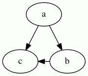

*Valid on:*

- Edges

*Note: dot only.*

### Damping

Factor damping force motions.

type: *double, default: `0.99`, minimum: `0.0`*

On each iteration, a node's movement is limited to this factor of its potential motion. By being less than `1.0`, the system tends to "cool", thereby preventing cycling.

*Valid on:*

- Graphs

*Note: neato only.*

### decorate

Whether to connect the edge label to the edge with a line

type: *bool, default: `false`*

If true, attach edge label to edge by a 2-segment polyline, underlining the label, then going to the closest point of spline.

Example

```
digraph {
  a -> a [label="AA" decorate=true]
  a -> b [label="AB" decorate=true]
  b -> b [label="BB" decorate=false]
}
```

Edit in Playground

*Valid on:*

- Edges

### defaultdist

The distance between nodes in separate connected components

type: *double, default: `1+(avg. len)*sqrt(|V|)`, minimum: `epsilon`*

If set too small, connected components may overlap.

Only applicable if `pack=false`.

*Valid on:*

- Graphs

*Note: neato only.*

### dim

Set the number of dimensions used for the layout

type: *int, default: `2`, minimum: `2`*

The maximum value allowed is `10`.

*Valid on:*

- Graphs

*Note: neato, fdp, sfdp only.*

### dimen

Set the number of dimensions used for rendering

type: *int, default: `2`, minimum: `2`*

The maximum value allowed is `10`.

If both `dimen` and `dim` are set, the latter specifies the dimension used for layout, and the former for rendering. If only `dimen` is set, this is used for both layout and rendering dimensions.

Note that, at present, all aspects of rendering are 2D. This includes the shape and size of nodes, overlap removal, and edge routing. Thus, for `dimen > 2`, the only valid information is the `pos` attribute of the nodes.

All other coordinates will be 2D and, at best, will reflect a projection of a higher-dimensional point onto the plane.

*Valid on:*

- Graphs

*Note: neato, fdp, sfdp only.*

### dir

Edge type for drawing arrowheads

type: *dirType, default: `forward` (directed) , `none` (undirected)*

Indicates which ends of the edge should be decorated with an arrowhead.

The actual style of the arrowhead can be specified using the `arrowhead` and `arrowtail` attributes.

See limitation.

Example

```
digraph {
  A->B [dir=forward]
  C->D [dir=back]
  E->F [dir=both]
  G->H [dir=none]
}
```

[Edit in Playground](https://magjac.com/graphviz-visual-editor/?dot=digraph%20%7b%0a%20%20A-%3eB%20%5bdir%3dforward%5d%0a%20%20C-%3eD%20%5bdir%3dback%5d%0a%20%20E-%3eF%20%5bdir%3dboth%5d%0a%20%20G-%3eH%20%5bdir%3dnone%5d%0a%7d)

*Valid on:*

- Edges

### diredgeconstraints

Whether to constrain most edges to point downwards

type: *string | bool, default: `false`*

If true, constraints are generated for each edge in the largest (heuristic) directed acyclic subgraph such that the edge must point downwards.

Only valid when `mode="ipsep"`.

If `hier`, generates level constraints similar to those used with `mode="hier"`. The main difference is that, in the latter case, only these constraints are involved, so a faster solver can be used.

*Valid on:*

- Graphs

*Note: neato only.*

### distortion

Distortion factor for `shape=polygon`

type: *double, default: `0.0`, minimum: `-100.0`*

Positive values cause top part to be larger than bottom; negative values do the opposite.

See also `skew`.

Example

```
graph {
  LargeBottom [shape=polygon sides=4 distortion=-.5]
  LargeTop    [shape=polygon sides=4 distortion=.5]
}
```

Edit in Playground

*Valid on:*

- Nodes

### dpi

Specifies the expected number of pixels per inch on a display device

type: *double, default: `96.0`, minimum: `0.0`*

For `bitmap` output, `dpi` guarantees that text rendering will be done more accurately, both in size and in placement.

For SVG output, `dpi` guarantees the dimensions in the output correspond to the correct number of points or inches.

*Valid on:*

- Graphs

*Note: bitmap output, svg only.*

### edgehref

Synonym for `edgeURL`

type: *escString, default: `""`*

See also:

- `edgehref`, `edgeURL`
- `headhref`, `headURL`
- `labelhref`, `labelURL`
- `tailhref`, `tailURL`
- `href`, `URL`

*Valid on:*

- Edges

*Note: map, svg only.*

### edgetarget

Browser window to use for the `edgeURL` link

type: *escString, default: `<none>`*

If the edge has a `URL` or `edgeURL` attribute, `edgetarget` determines which window of the browser is used for the URL attached to the non-label part of the edge.

Setting `edgetarget=_graphviz` will open a new window if it doesn't already exist, or reuse it if it does.

If undefined, the value of the `target` is used instead.

*Valid on:*

- Edges

*Note: map, svg only.*

### edgetooltip

Tooltip annotation attached to the non-label part of an edge

type: *escString, default: `""`*

- `headtooltip`.
- `labeltooltip`.
- `tailtooltip`.
- `tooltip`.

*Valid on:*

- Edges

*Note: cmap, svg only.*

### edgeURL

The link for the non-label parts of an edge

type: *escString, default: `""`*

`edgeURL` overrides any `URL` defined for the edge.

Also, `edgeURL` is used near the head or tail node unless overridden by `headURL` or `tailURL`, respectively.

See limitation.

See also:

- `edgehref`, `edgeURL`
- `headhref`, `headURL`
- `labelhref`, `labelURL`
- `tailhref`, `tailURL`
- `href`, `URL`

*Valid on:*

- Edges

*Note: map, svg only.*

### epsilon

Terminating condition

type: *double, default: `.0001 * # nodes` (mode == KK) , `.0001` (mode == major) , `.01` (mode == sgd)*

If the length squared of all energy gradients are less than `epsilon`, the algorithm stops.

*Valid on:*

- Graphs

*Note: neato only.*

### esep

Margin used around polygons for purposes of spline edge routing

type: *addDouble | addPoint, default: `+3`*

The interpretation is the same as given for `sep`. `esep` should normally be strictly less than `sep`.

*Valid on:*

- Graphs

*Note: neato, fdp, sfdp, osage, circo, twopi only.*

### fillcolor

Color used to fill the background of a node or cluster

type: *color | colorList, default: `lightgrey` (nodes) , `black` (clusters)*

Assuming `style=filled`, or a filled `arrowhead`.

If `fillcolor` is not defined, `color` is used. (For clusters, if `color` is not defined, `bgcolor` is used.) If this is not defined, the default is used, except for `shape=point` or when the output format is `MIF`, which use black by default.

If the value is a `colorList`, a gradient fill is used. By default, this is a linear fill; setting `style=radial` will cause a radial fill. At present, only two colors are used. If the second color (after a colon) is missing, the default color is used for it.

See also the `gradientangle` attribute for setting the gradient angle.

Note that a cluster inherits the root graph's attributes if defined. Thus, if the root graph has defined a `fillcolor`, this will override a `color` or `bgcolor` attribute set for the cluster.

*Valid on:*

- Nodes
- Edges
- Clusters

### fixedsize

Whether to use the specified width and height attributes to choose node size (rather than sizing to fit the node contents)

type: *bool | string, default: `false`*

If `false`, the size of a node is determined by smallest width and height needed to contain its label and image, if any, with a margin specified by the `margin` attribute.

The width and height must also be at least as large as the sizes specified by the `width` and `height` attributes, which specify the minimum values for these parameters.

If `true`, the node size is specified by the values of the `width` and `height` attributes only and is not expanded to contain the text label. There will be a warning if the label (with margin) cannot fit within these limits.

If the `fixedsize` attribute is set to `shape`, the `width` and `height` attributes also determine the size of the node shape, but the label can be much larger. Both the label and shape sizes are used when avoiding node overlap, but all edges to the node ignore the label and only contact the node shape. No warning is given if the label is too large.

*Valid on:*

- Nodes

### fontcolor

Color used for text

type: *color, default: `black`*

*Valid on:*

- Edges
- Nodes
- Graphs
- Clusters

### fontname

Font used for text

type: *string, default: `"Times-Roman"`*

This very much depends on the output format and, for non-bitmap output such as PostScript or SVG, the availability of the font when the graph is displayed or printed. As such, it is best to rely on font faces that are generally available, such as Times-Roman, Helvetica or Courier.

How font names are resolved also depends on the underlying library that handles font name resolution. If Graphviz was built using the [fontconfig library](https://www.freedesktop.org/wiki/Software/fontconfig/), the latter library will be used to search for the font. See the commands `fc-list`, `fc-match` and the other fontconfig commands for how names are resolved and which fonts are available. Other systems may provide their own font package, such as Quartz for OS X.

Note that various font attributes, such as weight and slant, can be built into the font name. Unfortunately, the syntax varies depending on which font system is dominant. Thus, using `fontname="times bold italic"` will produce a bold, slanted Times font using Pango, the usual main font library. Alternatively, `fontname="times:italic"` will produce a slanted Times font from fontconfig, while `fontname="times-bold"` will resolve to a bold Times using Quartz. You will need to ascertain which package is used by your Graphviz system and refer to the relevant documentation.

If Graphviz is not built with a high-level font library, fontname will be considered the name of a Type 1 or True Type font file. If you specify `fontname=schlbk`, the tool will look for a file named `schlbk.ttf` or `schlbk.pfa` or `schlbk.pfb` in one of the directories specified by the `fontpath` attribute. The lookup does support various aliases for the common fonts.

```
digraph {
    label="Comic Sans MS"
    fontname="Comic Sans MS"
    subgraph cluster_a {
      label="Courier New"
      fontname="Courier New"
      Arial [fontname="Arial"];
      Arial -> Arial [label="Impact" fontname="Impact"]
    }
}
```

Edit in Playground

*Valid on:*

- Edges
- Nodes
- Graphs
- Clusters

### fontnames

Allows user control of how basic fontnames are represented in SVG output

type: *string, default: `""`*

If `fontnames` is undefined or `hd`, fontconfig font conventions are used. The default `Times-Roman` font will be mapped to an equivalent available system font, such as `Times New Roman` (Windows) or `Times` (some Linux).

If `fontnames` is set to `svg`, the output will use known SVG fontnames. If `fontnames` is set to `ps`, PostScript font names like `Times-Roman` are used directly.

In all cases, the basic SVG font `serif` is used as a fallback for the named font. (So, a diagram containing text in `Times-Roman` might have that text represented in the SVG output by a `<text>` tag with the attribute `font-family="Times-Roman,serif"`.)

*Valid on:*

- Graphs

*Note: svg only.*

### fontpath

Directory list used by [libgd](https://libgd.github.io/) to search for bitmap fonts

type: *string, default: `<system-dependent>`*

Used if Graphviz was not built with the [fontconfig library](https://www.freedesktop.org/wiki/Software/fontconfig/).

If `fontpath` is not set, the environment variable `DOTFONTPATH` is checked.

If `DOTFONTPATH` is not set, `GDFONTPATH` is checked.

If `GDFONTPATH` not set, libgd uses its compiled-in font path.

Note that `fontpath` is an attribute of the root graph.

*Valid on:*

- Graphs

### fontsize

Font size, in points, used for text

type: *double, default: `14.0`, minimum: `1.0`*

```
digraph {
    label="40pt Graph Label"
    fontsize="40"
    subgraph cluster_a {
      label="30pt Cluster Label"
      fontsize="30pt"
      "20pt Node" [fontsize="20pt"];
      "20pt Node"-> "20pt Node" [label="10pt Edge" fontsize="10"]
    }
}
```

Edit in Playground

*Valid on:*

- Edges
- Nodes
- Graphs
- Clusters

### forcelabels

Whether to force placement of all `xlabels`, even if overlapping

type: *bool, default: `true`*

If true, all `xlabel` attributes are placed, even if there is some overlap with nodes or other labels.

*Valid on:*

- Graphs

### gradientangle

If a gradient fill is being used, this determines the angle of the fill

type: *int, default: `0`, minimum: `0`*

For linear fills, the colors transform along a line specified by the angle and the center of the object. For radial fills, a value of zero causes the colors to transform radially from the center; for non-zero values, the colors transform from a point near the object's periphery as specified by the value.

If unset, the default angle is 0.

*Valid on:*

- Nodes
- Clusters
- Graphs

### group

Name for a group of nodes, for bundling edges avoiding crossings.

type: *string, default: `""`*

If the end points of an edge belong to the same group, i.e., have the same `group` attribute, parameters are set to avoid crossings and keep the edges straight.

*Valid on:*

- Nodes

*Note: dot only.*

### head_lp

Center position of an edge's head label

type: *point*

In points.

*Valid on:*

- Edges

*Note: write only.*

### headclip

If true, the head of an edge is clipped to the boundary of the head node

type: *bool, default: `true`*

Otherwise, the end of the edge goes to the center of the node, or the center of a port, if applicable.

*Valid on:*

- Edges

### headhref

Synonym for `headURL`

type: *escString, default: `""`*

See also:

- `edgehref`, `edgeURL`
- `headhref`, `headURL`
- `labelhref`, `labelURL`
- `tailhref`, `tailURL`
- `href`, `URL`

*Valid on:*

- Edges

*Note: map, svg only.*

### headlabel

Text label to be placed near head of edge

type: *lblString, default: `""`*

See limitation.

*Valid on:*

- Edges

### headport

Indicates where on the head node to attach the head of the edge

type: *portPos, default: `center`*

In the default case, the edge is aimed towards the center of the node, and then clipped at the node boundary.

See limitation.

*Valid on:*

- Edges

### headtarget

Browser window to use for the `headURL` link

type: *escString, default: `<none>`*

If the edge has a `headURL`, `headtarget` determines which window of the browser is used for the URL. Setting `headURL=_graphviz` will open a new window if the window doesn't already exist, or reuse the window if it does.

If undefined, the value of the `target` is used.

*Valid on:*

- Edges

*Note: map, svg only.*

### headtooltip

Tooltip annotation attached to the head of an edge

type: *escString, default: `""`*

Used only if the edge has a `headURL` attribute.

See also:

- `edgetooltip`.
- `labeltooltip`.
- `tailtooltip`.
- `tooltip`.

*Valid on:*

- Edges

*Note: cmap, svg only.*

### headURL

If defined, `headURL` is output as part of the head label of the edge

type: *escString, default: `""`*

Also, this value is used near the head node, overriding any `URL` value.

See limitation.

See also:

- `edgehref`, `edgeURL`
- `headhref`, `headURL`
- `labelhref`, `labelURL`
- `tailhref`, `tailURL`
- `href`, `URL`

*Valid on:*

- Edges

*Note: map, svg only.*

### height

Height of node, in inches

type: *double, default: `0.5`, minimum: `0.02`*

This is taken as the initial, minimum height of the node. If `fixedsize` is true, this will be the final height of the node. Otherwise, if the node label requires more height to fit, the node's height will be increased to contain the label.

If the output format is `dot`, the value given to `height` will be the final value.

If the node shape is regular, the width and height are made identical:

- If both the `width` and the `height` are set explicitly, the maximum of the two values is used.
- If one of `width` or `height` is set explicitly, that value is used for both `width` and `height`.
- If neither is set explicitly, the minimum of the two default values is used.

If a value below the minimum value (0.02) is set, it will be rounded up to this minimum.

Height Example

```
digraph G {
  "default"
  "1in" [height=1]
  "2in" [height=2]
}
```

[Edit in Playground](https://magjac.com/graphviz-visual-editor/?dot=digraph%20G%20%7b%0a%20%20%22default%22%0a%20%20%221in%22%20%5bheight%3d1%5d%0a%20%20%222in%22%20%5bheight%3d2%5d%0a%7d)

See also:

- `width`

*Valid on:*

- Nodes

### href

Synonym for `URL`

type: *escString, default: `""`*

See also:

- `edgehref`, `edgeURL`
- `headhref`, `headURL`
- `labelhref`, `labelURL`
- `tailhref`, `tailURL`
- `href`, `URL`

*Valid on:*

- Graphs
- Clusters
- Nodes
- Edges

*Note: map, postscript, svg only.*

### id

Identifier for graph objects

type: *escString, default: `""`*

Allows the graph author to provide an identifier for graph objects which is to be included in the output.

Normal `\N`, `\E`, `\G` substitutions are applied.

If provided, it is the responsibility of the provider to keep `id` values unique for its intended downstream use.

Note, in particular, that `\E` does not provide a unique id for multi-edges.

If no `id` attribute is provided, then a unique internal id is used. However, this value is unpredictable by the graph writer.

If the graph provides an `id` attribute, this will be used as a prefix for internally generated attributes. By making internally-used attributes distinct, the user can include multiple image maps in the same document.

*Valid on:*

- Graphs
- Clusters
- Nodes
- Edges

*Note: map, postscript, svg only.*

### image

Gives the name of a file containing an image to be displayed inside a node

type: *string, default: `""`*

The image file must be in one of the recognized formats, typically JPEG, PNG, GIF, BMP, SVG, or Postscript, and be able to be converted into the desired output format.

The file must contain the image size information:

- Bitmap formats usually already contain image size.
- PostScript files must contain a line starting with `%%BoundingBox:` followed by four integers specifying the lower left x and y coordinates and the upper right x and y coordinates of the bounding box for the image, the coordinates being in points.
- An SVG image file must contain width and height attributes, typically as part of the svg element. The values for these should have the form of a floating point number, followed by optional units, e.g., `width="76pt"`. Recognized units are in, px, pc, pt, cm and mm for inches, pixels, picas, points, centimeters and millimeters, respectively. The default unit is points.

Unlike with the `shapefile` attribute, the image is treated as node content rather than the entire node. In particular, an image can be contained in a node of any shape, not just a rectangle.

Only paths to local resources are supported. If you want to use a URL to a remote resource, see the [`dot_url_resolve.py`](https://gitlab.com/graphviz/graphviz/-/blob/main/contrib/dot_url_resolve.py) script.

*Valid on:*

- Nodes

### imagepath

A list of directories in which to look for image files

type: *string, default: `""`*

When specified by the `image` attribute or using the `IMG` element in HTML-like labels.

`imagepath` should be a list of (absolute or relative) pathnames, each separated by a semicolon `;` (for Windows) or a colon `:` (all other OS).

The first directory in which a file of the given name is found will be used to load the image.

If `imagepath` is not set, relative pathnames for the image file will be interpreted with respect to the current working directory.

*Valid on:*

- Graphs

### imagepos

Controls how an image is positioned within its containing node

type: *string, default: `"mc"`*

`imagepos` only has an effect when the image is smaller than the containing node.

The default is to be centered both horizontally and vertically.

Valid values:

- `tl` - Top Left
- `tc` - Top Centered
- `tr` - Top Right
- `ml` - Middle Left
- `mc` - Middle Centered *(the default)*
- `mr` - Middle Right
- `bl` - Bottom Left
- `bc` - Bottom Centered
- `br` - Bottom Right

*Valid on:*

- Nodes

### imagescale

Controls how an image fills its containing node

type: *bool | string, default: `false`*

In general, the image is given its natural size, (cf. `dpi`), and the node size is made large enough to contain its image, its label, its margin, and its peripheries.

Its width and height will also be at least as large as its minimum `width` and `height`. If, however, `fixedsize=true`, the width and height attributes specify the exact size of the node.

- During rendering, in the default case (`imagescale=false`), the image retains its natural size.
- If `imagescale=true`, the image is uniformly scaled (i.e., its aspect ratio is preserved) to fit inside the node. At least one dimension of the image will be as large as possible given the size of the node.
- When `imagescale=width`, the width of the image is scaled to fill the node width.
- The corresponding property holds when `imagescale=height`.
- When `imagescale=both`, both the height and the width are scaled separately to fill the node.

In all cases, if a dimension of the image is larger than the corresponding dimension of the node, that dimension of the image is scaled down to fit the node.

As with the case of expansion, if `imagescale=true`, width and height are scaled uniformly.

*Valid on:*

- Nodes

### inputscale

Scales the input positions to convert between length units

type: *double, default: `<none>`*

For layout algorithms that support initial input positions (specified by the `pos` attribute), this attribute can be used to appropriately scale the values.

By default, `fdp` and `neato` interpret the x and y values of `pos` as being in inches. (**NOTE:** `neato -n(2)` treats the coordinates as being in points, being the unit used by the layout algorithms for the pos attribute.) Thus, if the graph has pos attributes in points, one should set `inputscale=72`. This can also be set on the command line using the `-s` flag.

If unset, no scaling is done and the units on input are treated as inches.

`inputscale=0` is equivalent to `inputscale=72`.

*Valid on:*

- Graphs

*Note: neato, fdp only.*

### K

Spring constant used in virtual physical model

type: *double, default: `0.3`, minimum: `0`*

It roughly corresponds to an ideal edge length (in inches), in that increasing `K` tends to increase the distance between nodes.

Note that the edge attribute `len` can be used to override this value for adjacent nodes.

*Valid on:*

- Graphs
- Clusters

*Note: fdp, sfdp only.*

### label

Text label attached to objects

type: *lblString, default: `"\N"` (nodes) , `""` (otherwise)*

If a node's `shape` is record, then the label can have a special format which describes the record layout.

Note that a node's default label is `"\N"`, so the node's name or ID becomes its label.

Technically, a node's name can be an HTML string but this will not mean that the node's label will be interpreted as an HTML-like label. This is because the node's actual label is an ordinary string, which will be replaced by the raw bytes stored in the node's name.

To get an HTML-like label, the label attribute value itself must be an HTML string.

Example: Van Gogh Paintings

```
graph {
  label="Vincent van Gogh Paintings"

  subgraph cluster_self_portraits {
    label="Self-portraits"

    spwgfh [label="Self-Portrait with Grey Felt Hat"]
    spaap [label="Self-Portrait as a Painter"]
  }

  subgraph cluster_flowers {
    label="Flowers"

    sf [label="Sunflowers"]
    ab [label="Almond Blossom"]
  }
}
```

Edit in Playground

*Valid on:*

- Edges
- Nodes
- Graphs
- Clusters

### label_scheme

Whether to treat a node whose name has the form `|edgelabel|*` as a special node representing an edge label.

type: *int, default: `0`, minimum: `0`*

- The default, `label_scheme=0`, produces no effect.
- If `label_scheme=1`, `sfdp` uses a penalty-based method to make that kind of node close to the center of its neighbor.
- With `label_scheme=2`, `sfdp` uses a penalty-based method to make that kind of node close to the old center of its neighbor.
- Finally, `label_scheme=3` invokes a two-step process of overlap removal and straightening.

*Valid on:*

- Graphs

*Note: sfdp only.*

### labelangle

The angle (in degrees) in polar coordinates of the head & tail edge labels.

type: *double, default: `-25.0`, minimum: `-180.0`*

Determines, along with `labeldistance`, where the `headlabel` / `taillabel` are placed with respect to the head / tail in polar coordinates.

The origin in the coordinate system is the point where the edge touches the node. The ray of 0 degrees goes from the origin back along the edge, parallel to the edge at the origin.

The angle, in degrees, specifies the rotation from the 0 degree ray, with positive angles moving counterclockwise and negative angles moving clockwise.

*Valid on:*

- Edges

### labeldistance

Scaling factor for the distance of `headlabel` / `taillabel` from the head / tail nodes.

type: *double, default: `1.0`, minimum: `0.0`*

The default distance is 10 points.

`labeldistance` multiplies that default.

See `labelangle` for more details.

*Valid on:*

- Edges

### labelfloat

If true, allows edge labels to be less constrained in position

type: *bool, default: `false`*

In particular, it may appear on top of other edges.

*Valid on:*

- Edges

### labelfontcolor

Color used for `headlabel` and `taillabel`.

type: *color, default: `black`*

If not set, defaults to edge's `fontcolor`.

*Valid on:*

- Edges

### labelfontname

Font for `headlabel` and `taillabel`

type: *string, default: `"Times-Roman"`*

Font used for `headlabel` and `taillabel`.

If not set, defaults to edge's `fontname`.

*Valid on:*

- Edges

### labelfontsize

Font size of `headlabel` and `taillabel`

type: *double, default: `14.0`, minimum: `1.0`*

Font size, in points, used for `headlabel` and `taillabel`.

If not set, defaults to edge's `fontsize`.

*Valid on:*

- Edges

### labelhref

Synonym for `labelURL`

type: *escString, default: `""`*

See also:

- `edgehref`, `edgeURL`
- `headhref`, `headURL`
- `labelhref`, `labelURL`
- `tailhref`, `tailURL`
- `href`, `URL`

*Valid on:*

- Edges

*Note: map, svg only.*

### labeljust

Justification for graph & cluster labels

type: *string, default: `"c"`*

- If `labeljust=r`, the label is right-justified within bounding rectangle
- If `labeljust=l`, left-justified
- Else the label is centered.

Note that a subgraph inherits attributes from its parent. Thus, if the root graph sets `labeljust=l`, the subgraph inherits this value.

Graph label justifications

```
digraph {
  label="l"
  labeljust=l
  a
}
```

[Edit in Playground](https://magjac.com/graphviz-visual-editor/?dot=digraph%20%7b%0a%20%20label%3d%22l%22%0a%20%20labeljust%3dl%0a%20%20a%0a%7d)

Graph label justifications

```
digraph {
  label="r"
  labeljust=r
  b
}
```

[Edit in Playground](https://magjac.com/graphviz-visual-editor/?dot=digraph%20%7b%0a%20%20label%3d%22r%22%0a%20%20labeljust%3dr%0a%20%20b%0a%7d)

Cluster label justifications

```
digraph {
  subgraph cluster_l {
    label="l"
    labeljust=l
    a
  }
  subgraph cluster_c {
    label="c"
    labeljust=c
    b
  }
  subgraph cluster_r {
    label="r"
    labeljust=r
    c
  }
}
```

Edit in Playground

*Valid on:*

- Graphs
- Clusters

### labelloc

Vertical placement of labels for nodes, root graphs and clusters

type: *string, default: `"t"` (clusters) , `"b"` (root graphs) , `"c"` (nodes)*

For graphs and clusters, only `labelloc=t` and `labelloc=b` are allowed, corresponding to placement at the top and bottom, respectively.

By default, root graph labels go on the bottom and cluster labels go on the top.

Note that a subgraph inherits attributes from its parent. Thus, if the root graph sets `labelloc=b`, the subgraph inherits this value.

For nodes, this attribute is used only when the height of the node is larger than the height of its label.

If `labelloc=t`, `labelloc=c`, `labelloc=b`, the label is aligned with the top, centered, or aligned with the bottom of the node, respectively.

By default, the label is vertically centered.

Label at top of graph

```
digraph {
  labelloc="t"
  label="Title"
  a -> b
}
```

[Edit in Playground](https://magjac.com/graphviz-visual-editor/?dot=digraph%20%7b%0a%20%20labelloc%3d%22t%22%0a%20%20label%3d%22Title%22%0a%20%20a%20-%3e%20b%0a%7d)

Label at bottom of graph

```
digraph {
  labelloc="b"
  label="Title"
  a -> b
}
```

[Edit in Playground](https://magjac.com/graphviz-visual-editor/?dot=digraph%20%7b%0a%20%20labelloc%3d%22b%22%0a%20%20label%3d%22Title%22%0a%20%20a%20-%3e%20b%0a%7d)

Cluster Label Locations

```
digraph {
  label="Graph Title"
  subgraph cluster_t {
    labelloc="t"
    label="Cluster Top"
    a -> b
  }
  subgraph cluster_b {
    labelloc="b"
    label="Cluster Bottom"
    c -> d
  }
}
```

Edit in Playground

Node label positions

```
digraph {
  t [labelloc=t]
  c [labelloc=c]
  b [labelloc=b]
}
```

[Edit in Playground](https://magjac.com/graphviz-visual-editor/?dot=digraph%20%7b%0a%20%20t%20%5blabelloc%3dt%5d%0a%20%20c%20%5blabelloc%3dc%5d%0a%20%20b%20%5blabelloc%3db%5d%0a%7d)

*Valid on:*

- Nodes
- Graphs
- Clusters

### labeltarget

Browser window to open `labelURL` links in

type: *escString, default: `<none>`*

If the edge has a `URL` or `labelURL` attribute, this attribute determines which window of the browser is used for the URL attached to the label.

Setting `labeltarget=_graphviz` will open a new window if it doesn't already exist, or reuse it if it does.

If undefined, the value of the `target` is used.

*Valid on:*

- Edges

*Note: map, svg only.*

### labeltooltip

Tooltip annotation attached to label of an edge

type: *escString, default: `""`*

- `edgetooltip`.
- `headtooltip`.
- `tailtooltip`.
- `tooltip`.

*Valid on:*

- Edges

*Note: cmap, svg only.*

### labelURL

If defined, `labelURL` is the link used for the label of an edge

type: *escString, default: `""`*

`labelURL` overrides any `URL` defined for the edge.

See also:

- `edgehref`, `edgeURL`
- `headhref`, `headURL`
- `labelhref`, `labelURL`
- `tailhref`, `tailURL`
- `href`, `URL`

*Valid on:*

- Edges

*Note: map, svg only.*

### landscape

If true, the graph is rendered in landscape mode

type: *bool, default: `false`*

Synonymous with `rotate=90` or `orientation=landscape`.

Rotations

```
digraph {
  landscape=true
  a -> b
}
```

[Edit in Playground](https://magjac.com/graphviz-visual-editor/?dot=digraph%20%7b%0a%20%20landscape%3dtrue%0a%20%20a%20-%3e%20b%0a%7d)

See also:

- `rotate`
- `orientation`

*Valid on:*

- Graphs

### layer

Specifies layers in which the node, edge or cluster is present

type: *layerRange, default: `""`*

*Valid on:*

- Edges
- Nodes
- Clusters

### layerlistsep

The separator characters used to split attributes of type `layerRange` into a list of ranges.

type: *string, default: `","`*

*Valid on:*

- Graphs

### layers

A linearly ordered list of layer names attached to the graph

type: *layerList, default: `""`*

The graph is then output in separate layers. Only those components belonging to the current output layer appear.

See [How to use drawing layers (overlays)](https://www.graphviz.org/faq/#FaqOverlays).

*Valid on:*

- Graphs

### layerselect

Selects a list of layers to be emitted

type: *layerRange, default: `""`*

*Valid on:*

- Graphs

### layersep

The separator characters for splitting the `layers` attribute into a list of layer names.

type: *string, default: `":\t "`*

*Valid on:*

- Graphs

### layout

Which layout engine to use

type: *string, default: `""`*

Specifies the name of the layout engine to use, such as `dot` or `neato`.

Normally, graphs should be kept independent of a type of layout. In some cases, however, it can be convenient to embed the type of layout desired within the graph.

For example, a graph containing position information from a layout might want to record what the associated layout engine was.

This attribute takes precedence over the `-K` flag or the actual command name used.

*Valid on:*

- Graphs

### len

Preferred edge length, in inches

type: *double, default: `1.0` (neato) , `0.3` (fdp)*

See also:

- `minlen`

*Valid on:*

- Edges

*Note: neato, fdp only.*

### levels

Number of levels allowed in the multilevel scheme

type: *int, default: `INT_MAX`, minimum: `0.0`*

*Valid on:*

- Graphs

*Note: sfdp only.*

### levelsgap

strictness of neato level constraints

type: *double, default: `0.0`*

Specifies strictness of level constraints in `neato` when `mode="ipsep"` or `mode=hier`.

Larger positive values mean stricter constraints, which demand more separation between levels. On the other hand, negative values will relax the constraints by allowing some overlap between the levels.

*Valid on:*

- Graphs

*Note: neato only.*

### lhead

Logical head of an edge

type: *string, default: `""`*

When `compound` is true, if `lhead` is defined and is the name of a cluster containing the real head, the edge is clipped to the boundary of the cluster.

```
digraph {
  compound=true;

  subgraph cluster_a {
    label="Cluster A";
    node1; node3; node5; node7;
  }
  subgraph cluster_b {
    label="Cluster B";
    node2; node4; node6; node8;
  }

  node1 -> node2 [label="1"];
  node3 -> node4 [label="2" ltail="cluster_a"];

  node5 -> node6 [label="3" lhead="cluster_b"];
  node7 -> node8 [label="4" ltail="cluster_a" lhead="cluster_b"];
}
```

Edit in Playground

See limitation.

*Valid on:*

- Edges

*Note: dot only.*

### lheight

Height of graph or cluster label, in inches

type: *double*

*Valid on:*

- Graphs
- Clusters

*Note: write only.*

### linelength

How long strings should get before overflowing to next line, for text output.

type: *int, default: `128`, minimum: `60`*

Example, where an 80-character long string (`"a " * 40`) is broken up onto two lines, when printed as canonical output:

```
$ echo 'digraph G { linelength=60; N0 [label="a a a a a a a a a a a a a a a a a a a a a a a a a a a a a a a a a a a a a a a a "]; }' | dot -Tcanon
digraph G {
        graph [linelength=60];
        node [label="\N"];
        N0      [label="a a a a a a a a a a a a a a a a a a a a a a a a a a a a a a \
a a a a a a a a a a "];
}
```

The text overflows when the *label* reaches the given size.

Despite the `linelength` name, this is the length of the attribute string, *not* the length of the overall line (which includes the node ID and attribute key).

*Valid on:*

- Graphs

### lp

Label center position

type: *point*

Label center position, in points.

*Valid on:*

- Edges
- Graphs
- Clusters

*Note: write only.*

### ltail

Logical tail of an edge

type: *string, default: `""`*

When `compound=true`, if `ltail` is defined and is the name of a cluster containing the real tail, the edge is clipped to the boundary of the cluster.

```
digraph {
  compound=true;

  subgraph cluster_a {
    label="Cluster A";
    node1; node3; node5; node7;
  }
  subgraph cluster_b {
    label="Cluster B";
    node2; node4; node6; node8;
  }

  node1 -> node2 [label="1"];
  node3 -> node4 [label="2" ltail="cluster_a"];

  node5 -> node6 [label="3" lhead="cluster_b"];
  node7 -> node8 [label="4" ltail="cluster_a" lhead="cluster_b"];
}
```

Edit in Playground

See limitation.

*Valid on:*

- Edges

*Note: dot only.*

### lwidth

Width of graph or cluster label, in inches

type: *double*

*Valid on:*

- Graphs
- Clusters

*Note: write only.*

### margin

For graphs, this sets x and y margins of canvas, in inches

type: *double | point, default: `<device-dependent>`*

If the margin is a single double, both margins are set equal to the given value.

Note that the margin is not part of the drawing but just empty space left around the drawing. The margin basically corresponds to a translation of drawing, as would be necessary to center a drawing on a page. Nothing is actually drawn in the margin. To actually extend the background of a drawing, see the `pad` attribute.

For clusters, `margin` specifies the space between the nodes in the cluster and the cluster bounding box. By default, this is 8 points.

For nodes, this attribute specifies space left around the node's label. By default, the value is `0.11,0.055`.

Nodes Example: Wide Margins, Tall Margins, and Equal Margins

```
graph {
  "1.5x0.5" [shape=rect margin="1.5,0.5"] # in inches
  "0.5x1.5" [shape=rect margin="0.5,1.5"] # in inches
  "1.5x1.5" [shape=rect margin="1.5"]     # in inches
}
```

Edit in Playground

Example: Cluster and Graph Margins

```
graph {
    bgcolor=lightgray
    margin=0 # in inches

    subgraph cluster_one {
      margin=8 # in points
      a
      b
    }
    subgraph cluster_two {
      margin=16 # in points
      c
      d
    }
}
```

Edit in Playground

*Valid on:*

- Nodes
- Clusters
- Graphs

### maxiter

Sets the number of iterations used

type: *int, default: `100 * # nodes` (mode == KK) , `200` (mode == major) , `30` (mode == sgd) , `600` (fdp)*

*Valid on:*

- Graphs

*Note: neato, fdp only.*

### mclimit

Scale factor for mincross (mc) edge crossing minimizer parameters

type: *double, default: `1.0`*

Multiplicative scale factor used to alter the `MinQuit` (default = 8) and `MaxIter` (default = 24) parameters used during crossing minimization.

These correspond to the number of tries without improvement before quitting and the maximum number of iterations in each pass.

*Valid on:*

- Graphs

*Note: dot only.*

### mindist

Specifies the minimum separation between all nodes

type: *double, default: `1.0`, minimum: `0.0`*

*Valid on:*

- Graphs

*Note: circo only.*

### minlen

Minimum edge length (rank difference between head and tail)

type: *int, default: `1`, minimum: `0`*

See also:

- `len`

*Valid on:*

- Edges

*Note: dot only.*

### mode

Technique for optimizing the layout

type: *string, default: `major`*

`neato` supports modes:

- `mode="major"`: `neato` uses stress majorization<sup>1</sup>.
- `mode="KK"`: `neato` uses the Kamada-Kawai<sup>2</sup> version of the gradient descent method. `KK` is sometimes appreciably faster for small (number of nodes < 100) graphs. A significant disadvantage is that `KK` may cycle.
- `mode="sgd"`: `neato` uses a version of the Stochastic Gradient Descent<sup>3</sup> method. `sgd`'s advantage is faster and more reliable convergence than both the previous methods, while `sgd`'s disadvantage is that it runs in a fixed number of iterations and may require larger values of `maxiter` in some graphs.

There are two experimental modes in `neato`:

- `mode="hier"`, which adds a top-down directionality similar to the layout used in `dot`, and
- `mode="ipsep"`, which allows the graph to specify minimum vertical and horizontal distances between nodes. (See the `sep` attribute.)
[^1]: Gansner, E.R., Koren, Y., North, S. (2005). Graph Drawing by Stress Majorization. In: Pach, J. (eds) Graph Drawing. GD 2004. Lecture Notes in Computer Science, vol 3383. Springer, Berlin, Heidelberg.
[^2]: [Tomihisa Kamada, Satoru Kawai, An algorithm for drawing general undirected graphs, Information Processing Letters, Volume 31, Issue 1, 1989, Pages 7-15.](https://doi.org/10.1016%2F0020-0190%2889%2990102-6)
[^3]: [J. X. Zheng, S. Pawar and D. F. M. Goodman, "Graph Drawing by Stochastic Gradient Descent," in IEEE Transactions on Visualization and Computer Graphics, vol. 25, no. 9, pp. 2738-2748, 1 Sept. 2019, doi: 10.1109/TVCG.2018.2859997.](https://ieeexplore.ieee.org/document/8419285)

*Valid on:*

- Graphs

*Note: neato only.*

### model

Specifies how the distance matrix is computed for the input graph

type: *string, default: `shortpath`*

The distance matrix specifies the ideal distance between every pair of nodes. `neato` attempts to find a layout which best achieves these distances. By default, it uses the length of the shortest path, where the length of each edge is given by its `len` attribute.

- If `model="circuit"`, neato uses the circuit resistance model to compute the distances. This tends to emphasize clusters.
- If `model="subset"`, neato uses the subset model. This sets the edge length to be the number of nodes that are neighbors of exactly one of the end points, and then calculates the shortest paths. This helps to separate nodes with high degree.

For more control of distances, one can use `model=mds`. In this case, the `len` of an edge is used as the ideal distance between its vertices.

A shortest path calculation is only used for pairs of nodes not connected by an edge. Thus, by supplying a complete graph, the input can specify all of the relevant distances.

*Valid on:*

- Graphs

*Note: neato only.*

### newrank

Whether to use a single global ranking, ignoring clusters

type: *bool, default: `false`*

The original ranking algorithm in `dot` is recursive on clusters. This can produce fewer ranks and a more compact layout, but sometimes at the cost of a head node being place on a higher rank than the tail node. It also assumes that a node is not constrained in separate, incompatible subgraphs. For example, a node cannot be in a cluster and also be constrained by `rank=same` with a node not in the cluster.

This allows nodes to be subject to multiple constraints. Rank constraints will usually take precedence over edge constraints.

*Valid on:*

- Graphs

*Note: dot only.*

### nodesep

In `dot`, `nodesep` specifies the minimum space between two adjacent nodes in the same rank, in inches

type: *double, default: `0.25`, minimum: `0.02`*

For other layouts, `nodesep` affects the spacing between loops on a single node, or multiedges between a pair of nodes.

Small node separation

```
digraph {
    nodesep=0.1;
    node1; node2; node3;
}
```

[Edit in Playground](https://magjac.com/graphviz-visual-editor/?dot=digraph%20%7b%0a%20%20%20%20nodesep%3d0.1%3b%0a%20%20%20%20node1%3b%20node2%3b%20node3%3b%0a%7d)

Large node separation

```
digraph {
    nodesep=0.5;
    node1; node2; node3;
}
```

[Edit in Playground](https://magjac.com/graphviz-visual-editor/?dot=digraph%20%7b%0a%20%20%20%20nodesep%3d0.5%3b%0a%20%20%20%20node1%3b%20node2%3b%20node3%3b%0a%7d)

*Valid on:*

- Graphs

### nojustify

Whether to justify multiline text vs the previous text line (rather than the side of the container).

type: *bool, default: `false`*

By default, the justification of multi-line labels is done within the largest context that makes sense. Thus, in the label of a polygonal node, a left-justified line will align with the left side of the node (shifted by the prescribed `margin`). In record nodes, left-justified line will line up with the left side of the enclosing column of fields. If `nojustify=true`, multi-line labels will be justified in the context of itself.

For example, if `nojustify` is set, the first label line is long, and the second is shorter and left-justified, the second will align with the left-most character in the first line, regardless of how large the node might be.

See this example containing the `\l` (left-justify) escape-string:

Nojustify causes text to align with previous text line, not left side of box

```
digraph G {
  node [width=3 shape=box]
  a [nojustify=false label="The first line is longer\nnojustify=false\l"]
  b [nojustify=true label="The first line is longer\nnojustify=true\l"]
  a -> b
}
```

Edit in Playground

Nojustify causes text to align with previous text line, not record column

```
digraph G{
  c [nojustify=false shape=record label="{Records Example - Long Line\n | Title - Shorter Line\nnojustify=false\l}"]
  d [nojustify=true shape=record label="{Records Example - Long Line\n | Title - Shorter Line\nnojustify=true\l}"]
  c -> d
}
```

Edit in Playground

*Valid on:*

- Graphs
- Clusters
- Nodes
- Edges

### normalize

normalizes coordinates of final layout

type: *double | bool, default: `false`*

So that the first point is at the origin, and then rotates the layout so that the angle of the first edge is specified by the value of `normalize` in degrees.

If `normalize` is not a number, it is evaluated as a bool, with `true` corresponding to `0` degrees.

**NOTE:** Since the attribute is evaluated first as a number, `0` and `1` cannot be used for `false` and `true`.

*Valid on:*

- Graphs

*Note: neato, fdp, sfdp, twopi, circo only.*

### notranslate

Whether to avoid translating layout to the origin point

type: *bool, default: `false`*

By default, the final layout is translated so that the lower-left corner of the bounding box is at the origin.

This can be annoying if some nodes are pinned or if the user runs `neato -n`.

To avoid this translation, set `notranslate=true`.

*Valid on:*

- Graphs

*Note: neato only.*

### nslimit

Sets number of iterations in network simplex applications

type: *double*

`nslimit` is used in computing `node x coordinates`.

If defined, `# iterations = nslimit * # nodes`; otherwise, `# iterations = INT_MAX`.

*Valid on:*

- Graphs

*Note: dot only.*

### nslimit1

Sets number of iterations in network simplex applications

type: *double*

`nslimit1` is used for ranking nodes.

If defined, `# iterations = nslimit * # nodes`; otherwise, `# iterations = INT_MAX`.

*Valid on:*

- Graphs

*Note: dot only.*

### oneblock

Whether to draw circo graphs around one circle.

type: *bool, default: `false`*

Observe two examples of rendering the same graph:

Example: Multiple Blocks

```
digraph G {
    layout="circo"
    oneblock=false

    N0 -> N1
    N1 -> N2
    N2 -> N3
    N3 -> N4
    N4 -> N0

    N4 -> N5
    N5 -> N6
    N6 -> N7
    N7 -> N8
    N8 -> N5
}
```

Edit in Playground

Example: One Block

```
digraph G {
    layout="circo"
    oneblock=true

    N0 -> N1
    N1 -> N2
    N2 -> N3
    N3 -> N4
    N4 -> N0

    N4 -> N5
    N5 -> N6
    N6 -> N7
    N7 -> N8
    N8 -> N5
}
```

Edit in Playground

*Valid on:*

- Graphs

*Note: circo only.*

### ordering

Constrains the left-to-right ordering of node edges.

type: *string, default: `""`*

If `ordering="out"`, then the outedges of a node, that is, edges with the node as its tail node, must appear left-to-right in the same order in which they are defined in the input.

If `ordering="in"`, then the inedges of a node must appear left-to-right in the same order in which they are defined in the input.

If defined as a graph or subgraph attribute, the value is applied to all nodes in the graph or subgraph.

Note that the graph attribute takes precedence over the node attribute.

*Valid on:*

- Graphs
- Nodes

*Note: dot only.*

### orientation

node shape rotation angle, or graph orientation

type: *double | string, default: `0.0`, `""`, minimum: `-360.0`*

When used on nodes: Angle, in degrees, to rotate polygon node shapes. For any number of polygon sides, 0 degrees rotation results in a flat base. When used on graphs: If `"[lL]*"`, sets graph orientation to landscape.

Used only if `rotate` is not defined.

Node Orientations

```
digraph {
  layout=neato       # Render in a circular layout
  node [shape=house] # Make all nodes have 'house' shape

    0 [orientation=0]
   45 [orientation=45]
   90 [orientation=90]
  135 [orientation=135]
  180 [orientation=180]
  225 [orientation=225]
  270 [orientation=270]
  315 [orientation=315]
  0 -> 45 -> 90 -> 135 -> 180 -> 225 -> 270 -> 315 -> 0
}
```

Edit in Playground

Landscape Graph Orientation

```
digraph {
  orientation=L
  a -> b
}
```

[Edit in Playground](https://magjac.com/graphviz-visual-editor/?dot=digraph%20%7b%0a%20%20orientation%3dL%0a%20%20a%20-%3e%20b%0a%7d)

See also:

- `orientation`
- `rotate`

*Valid on:*

- Nodes
- Graphs

### outputorder

Specify order in which nodes and edges are drawn

type: *outputMode, default: `breadthfirst`*

*Valid on:*

- Graphs

### overlap

Determines if and how node overlaps should be removed

type: *string | bool, default: `true`*

Nodes are first enlarged using the `sep` attribute. If `true` , overlaps are retained. If the value is `"scale"`, overlaps are removed by uniformly scaling in x and y. If the value converts to `"false"`, and it is available, Prism, a proximity graph-based algorithm, is used to remove node overlaps. This can also be invoked explicitly with `overlap=prism`. This technique starts with a small scaling up, controlled by the `overlap_scaling` attribute, which can remove a significant portion of the overlap. The prism option also accepts an optional non-negative integer suffix. This can be used to control the number of attempts made at overlap removal. By default, `overlap="prism"` is equivalent to `overlap="prism1000"`. Setting `overlap="prism0"` causes only the scaling phase to be run.

If Prism is not available, or the version of Graphviz is earlier than 2.28, `"overlap=false"` uses a Voronoi-based technique. This can always be invoked explicitly with `"overlap=voronoi"`.

If `overlap="scalexy"`, x and y are separately scaled to remove overlaps.

If `overlap="compress"`, the layout will be scaled down as much as possible without introducing any overlaps, obviously assuming there are none to begin with.

**N.B.** The remaining allowed values of `overlap` correspond to algorithms which, at present, can produce bad aspect ratios. In addition, we deprecate the use of the `"ortho*"` and `"portho*"`.

If the value is `"vpsc"`, overlap removal is done as a quadratic optimization to minimize node displacement while removing node overlaps.

If the value is `"orthoxy"` or `"orthoyx"`, overlaps are moved by optimizing two constraint problems, one for the x axis and one for the y. The suffix indicates which axis is processed first. If the value is "ortho", the technique is similar to "orthoxy" except a heuristic is used to reduce the bias between the two passes. If the value is `"ortho_yx"`, the technique is the same as `"ortho"`, except the roles of x and y are reversed. The values `"portho"`, `"porthoxy"`, `"porthoxy"`, and `"portho_yx"` are similar to the previous four, except only pseudo-orthogonal ordering is enforced.

If the layout is done by neato with `mode="ipsep"`, then one can use `overlap=ipsep`. In this case, the overlap removal constraints are incorporated into the layout algorithm itself. N.B. At present, this only supports one level of clustering.

Except for `fdp` and `sfdp`, the layouts assume `overlap="true"` as the default. Fdp first uses a number of passes using a built-in, force-directed technique to try to remove overlaps. Thus, `fdp` accepts `overlap` with an integer prefix followed by a colon, specifying the number of tries. If there is no prefix, no initial tries will be performed. If there is nothing following a colon, none of the above methods will be attempted. By default, `fdp` uses `overlap="9:prism"`. Note that `overlap="true"`, `overlap="0:true"` and `overlap="0:"` all turn off all overlap removal.

By default, `sfdp` uses `overlap="prism0"`.

Except for the Voronoi and prism methods, all of these transforms preserve the orthogonal ordering of the original layout. That is, if the x coordinates of two nodes are originally the same, they will remain the same, and if the x coordinate of one node is originally less than the x coordinate of another, this relation will still hold in the transformed layout. The similar properties hold for the y coordinates. This is not quite true for the `"porth*"` cases. For these, orthogonal ordering is only preserved among nodes related by an edge.

*Valid on:*

- Graphs

*Note: fdp, neato, sfdp, circo, twopi only.*

### overlap_scaling

Scale layout by factor, to reduce node overlap.

type: *double, default: `-4`, minimum: `-1e+10`*

When `overlap=prism`, the layout is scaled by this factor, thereby removing a fair amount of node overlap, and making node overlap removal faster and better able to retain the graph's shape.

- If `overlap_scaling` is negative, the layout is scaled by `-1*overlap_scaling` times the average label size.
- If `overlap_scaling` is positive, the layout is scaled by `overlap_scaling`.
- If `overlap_scaling` is zero, no scaling is done.

*Valid on:*

- Graphs

*Note: prism, neato, sfdp, fdp, circo, twopi only.*

### overlap_shrink

Whether the overlap removal algorithm should perform a compression pass to reduce the size of the layout

type: *bool, default: `true`*

*Valid on:*

- Graphs

*Note: prism only.*

### pack

Whether each connected component of the graph should be laid out separately, and then the graphs packed together.

type: *bool | int, default: `false`*

If `pack` has an integral value, this is used as the size, in points,of a margin around each part; otherwise, a default margin of `8` is used.

If pack is interpreted as `false`, the entire graph is laid out together. The granularity and method of packing is influenced by the `packmode` attribute.

For layouts which always do packing, such as `twopi`, the `pack` attribute is just used to set the margin.

`pack` is treated as true if the value of pack is `true` (case-insensitive) or a non-negative integer.

*Valid on:*

- Graphs

### packmode

How connected components should be packed

type: *packMode, default: `node`*

(cf `packMode`). Note that defining `packmode` will automatically turn on packing as though one had set `pack=true`.

*Valid on:*

- Graphs

### pad

Inches to extend the drawing area around the minimal area needed to draw the graph

type: *double | point, default: `0.0555` (4 points)*

If `pad` is a single double, both the x and y pad values are set equal to the given value. This area is part of the drawing and will be filled with the background color, if appropriate.

Normally, a small `pad` is used for aesthetic reasons, especially when a background color is used, to avoid having nodes and edges abutting the boundary of the drawn region.

*Valid on:*

- Graphs

### page

Width and height of output pages, in inches

type: *double | point*

If only a single value is given, this is used for both the width and height.

If `page` is set and is smaller than the size of the layout, a rectangular array of pages of the specified page size is overlaid on the layout, with origins aligned in the lower-left corner, thereby partitioning the layout into pages. The pages are then produced one at a time, in `pagedir` order.

At present, `page` only works for PostScript output. For other types of output, use another tool to split the output into multiple output files, or use `viewport` to generate multiple files.

*Valid on:*

- Graphs

### pagedir

The order in which pages are emitted

type: *pagedir, default: `BL`*

Used only if `page` is set and applicable.

Limited to one of the 8 row or column major orders.

*Valid on:*

- Graphs

### pencolor

Color used to draw the bounding box around a cluster

type: *color, default: `black`*

If `pencolor` is not defined, `color` is used.

If `color` is not defined, `bgcolor` is used.

If `bgcolor` is not defined, the default is used.

Note that a cluster inherits the root graph's attributes if defined. Thus, if the root graph has defined a `pencolor`, this will override a `color` or `bgcolor` attribute set for the cluster.

*Valid on:*

- Clusters

### penwidth

Specifies the width of the pen, in points, used to draw lines and curves

type: *double, default: `1.0`, minimum: `0.0`*

including the boundaries of edges and clusters.

`penwidth` value is inherited by subclusters, and has no effect on text.

Previous to 31 January 2008, the effect of `penwidth=W` was achieved by including `setlinewidth(W)` as part of a `style` specification.

If both attributes are set, `penwidth` will be used.

*Valid on:*

- Clusters
- Nodes
- Edges

### peripheries

Set number of peripheries used in polygonal shapes and cluster boundaries

type: *int, default: `<shape default>` (nodes) , `1` (clusters) , minimum: `0`*

Note that user-defined shapes are treated as a form of box shape, so the default peripheries value is 1 and the user-defined shape will be drawn in a bounding rectangle. Setting `peripheries=0` will turn this off.

`peripheries=1` is the maximum value for clusters.

*Valid on:*

- Nodes
- Clusters

### pin

Keeps the node at the node's given input position

type: *bool, default: `false`*

If true and the node has a `pos` attribute on input, `neato` or `fdp` prevents the node from moving from the input position. This property can also be specified in the `pos` attribute itself (cf. the point type).

**Note:** Due to an artifact of the implementation, previous to 27 Feb 2014, final coordinates are translated to the origin. Thus, if you look at the output coordinates given in the (x)dot or plain format, pinned nodes will not have the same output coordinates as were given on input. If this is important, a simple workaround is to maintain the coordinates of a pinned node. The vector difference between the old and new coordinates will give the translation, which can then be subtracted from all of the appropriate coordinates.

After 27 Feb 2014, this translation can be avoided in `neato` by setting `notranslate=true`. However, if the graph specifies node overlap removal or a change in aspect `ratio`, node coordinates may still change.

*Valid on:*

- Nodes

*Note: neato, fdp only.*

### pos

Position of node, or spline control points

type: *point | splineType*

For nodes, the position indicates the center of the node. On output, the coordinates are in points.

In `neato` and `fdp`, `pos` can be used to set the initial position of a node. By default, the coordinates are assumed to be in inches. However, the `-s` command line flag can be used to specify different units. As the output coordinates are in points, feeding the output of a graph laid out by a Graphviz program into `neato` or `fdp` will almost always require the `-s` flag.

When the `-n` command line flag is used with `neato`, it is assumed the positions have been set by one of the layout programs, and are therefore in points. Thus, `neato -n` can accept input correctly without requiring a `-s` flag and, in fact, ignores any such flag.

*Valid on:*

- Edges
- Nodes

*Note: neato, fdp only.*

### quadtree

Quadtree scheme to use

type: *quadType | bool, default: `normal`*

- `quadtree=true` aliases `quadtree=normal`
- `quadtree=false` aliases `quadtree=none`
- `quadtree=2` aliases `quadtree=fast`

*Valid on:*

- Graphs

*Note: sfdp only.*

### quantum

If `quantum > 0.0`, node label dimensions will be rounded to integral multiples of the quantum

type: *double, default: `0.0`, minimum: `0.0`*

*Valid on:*

- Graphs

### rank

Rank constraints on the nodes in a subgraph

type: *rankType*

- If `rank="same"`, all nodes are placed on the same rank.
- If `rank="min"`, all nodes are placed on the minimum rank.
- If `rank="source"`, all nodes are placed on the minimum rank, and the only nodes on the minimum rank belong to some subgraph with `rank="source"` or `rank="min"`.

Analogous criteria hold for `rank="max"` and `rank="sink"`.

(Note: the minimum rank is topmost or leftmost, and the maximum rank is bottommost or rightmost.)

For more information check [this answer in Stack Overflow](https://stackoverflow.com/a/6155783/3416774)

*Valid on:*

- Subgraphs

*Note: dot only.*

### rankdir

Sets direction of graph layout

type: *rankdir, default: `TB`*

For example, if `rankdir="LR"`, and barring cycles, an edge `T -> H;` will go from left to right. By default, graphs are laid out from top to bottom.

This attribute also has a side-effect in determining how record nodes are interpreted. See record shapes.

Top to bottom (default)

```
digraph {
    rankdir="TB"
    a -> b -> c;
}
```

[Edit in Playground](https://magjac.com/graphviz-visual-editor/?dot=digraph%20%7b%0a%20%20%20%20rankdir%3d%22TB%22%0a%20%20%20%20a%20-%3e%20b%20-%3e%20c%3b%0a%7d)

Bottom to top

```
digraph {
    rankdir="BT"
    a -> b -> c;
}
```

[Edit in Playground](https://magjac.com/graphviz-visual-editor/?dot=digraph%20%7b%0a%20%20%20%20rankdir%3d%22BT%22%0a%20%20%20%20a%20-%3e%20b%20-%3e%20c%3b%0a%7d)

Left to right

```
digraph {
    rankdir="LR"
    a -> b -> c;
}
```

[Edit in Playground](https://magjac.com/graphviz-visual-editor/?dot=digraph%20%7b%0a%20%20%20%20rankdir%3d%22LR%22%0a%20%20%20%20a%20-%3e%20b%20-%3e%20c%3b%0a%7d)

Right to left

```
digraph {
    rankdir="RL"
    a -> b -> c;
}
```

[Edit in Playground](https://magjac.com/graphviz-visual-editor/?dot=digraph%20%7b%0a%20%20%20%20rankdir%3d%22RL%22%0a%20%20%20%20a%20-%3e%20b%20-%3e%20c%3b%0a%7d)

*Valid on:*

- Graphs

*Note: dot only.*

### ranksep

Specifies separation between ranks

type: *double | doubleList, default: `0.5` (dot) , `1.0` (twopi) , minimum: `0.02`*

In `dot`, sets the desired rank separation, in inches.

This is the minimum vertical distance between the bottom of the nodes in one rank and the tops of nodes in the next. If the value contains `equally`, the centers of all ranks are spaced equally apart. Note that both settings are possible, e.g., `ranksep="1.2 equally"`.

In `twopi`, this attribute specifies the radial separation of concentric circles. For `twopi`, `ranksep` can also be a list of doubles. The first double specifies the radius of the inner circle; the second double specifies the increase in radius from the first circle to the second; etc. If there are more circles than numbers, the last number is used as the increment for the remainder.

*Valid on:*

- Graphs

*Note: dot, twopi only.*

### ratio

Sets the aspect ratio (drawing height/drawing width) for the drawing

type: *double | string*

Note that this is adjusted before the `size` attribute constraints are enforced.

In addition, the calculations usually ignore the node sizes, so the final drawing size may only approximate what is desired.

If `ratio` is numeric, `ratio` is taken as the desired aspect ratio. Then, if the actual aspect ratio is less than the desired ratio, the drawing height is scaled up to achieve the desired ratio; if the actual ratio is greater than that desired ratio, the drawing width is scaled up.

If `ratio="fill"` and the `size` attribute is set, node positions are scaled, separately in both x and y, so that the final drawing exactly fills the specified size. If both `size` values exceed the width and height of the drawing, then both coordinate values of each node are scaled up accordingly. However, if either size dimension is smaller than the corresponding dimension in the drawing, one dimension is scaled up so that the final drawing has the same aspect ratio as specified by `size`. Then, when rendered, the layout will be scaled down uniformly in both dimensions to fit the given `size`, which may cause nodes and text to shrink as well. This may not be what the user wants, but it avoids the hard problem of how to reposition the nodes in an acceptable fashion to reduce the drawing size.

If `ratio="compress"` and the `size` attribute is set, dot attempts to compress the initial layout to fit in the given size. This achieves a tighter packing of nodes but reduces the balance and symmetry. This feature only works in dot.

If `ratio="expand"`, the `size` attribute is set, and both the width and the height of the graph are less than the value in `size`, node positions are scaled uniformly until at least one dimension fits `size` exactly. Note that this is distinct from using `size` as the desired size, as here the drawing is expanded before edges are generated and all node and text sizes remain unchanged.

If `ratio="auto"`, the `page` attribute is set and the graph cannot be drawn on a single page, then `size` is set to an "ideal" value.

In particular, the size in a given dimension will be the smallest integral multiple of the page size in that dimension which is at least half the current size. The two dimensions are then scaled independently to the new size. This feature only works in `dot`.

*Valid on:*

- Graphs

### rects

Rectangles for fields of records, in points

type: *rect*

*Valid on:*

- Nodes

*Note: write only.*

### regular

If true, force polygon to be regular.

type: *bool, default: `false`*

If true, the vertices of the polygon will lie on a circle whose center is the center of the node.

```
digraph {
    "pentagon1" [shape="pentagon"];
    "pentagon2" [shape="pentagon" regular=true]
    "hexagon1" [shape="hexagon"];
    "hexagon2" [shape="hexagon" regular=true];
}
```

Edit in Playground

*Valid on:*

- Nodes

### remincross

If there are multiple clusters, whether to run edge crossing minimization a second time.

type: *bool, default: `true`*

*Valid on:*

- Graphs

*Note: dot only.*

### repulsiveforce

The power of the repulsive force used in an extended Fruchterman-Reingold

type: *double, default: `1.0`, minimum: `0.0`*

force directed model. Values larger than `1` tend to reduce the warping effect at the expense of less clustering.

*Valid on:*

- Graphs

*Note: sfdp only.*

### resolution

Synonym for `dpi`.

type: *double, default: `96.0`, minimum: `0.0`*

*Valid on:*

- Graphs

*Note: bitmap output, svg only.*

### root

Specifies nodes to be used as the center of the layout

type: *string | bool, default: `<none>` (graphs) , `false` (nodes)*

The center of the layout will be the root of the generated spanning tree.

- As a graph attribute, this gives the name of the node.
- As a node attribute, it specifies that the node should be used as a central node.

In `twopi`, `root` will actually be the central node. In `circo`, the block containing the node will be central in the drawing of its connected component. If not defined, `twopi` will pick a most central node, and `circo` will pick a random node.

If the root attribute is defined as the empty string, `twopi` will reset it to name of the node picked as the root node.

For `twopi`, it is possible to have multiple roots, presumably one for each component. If more than one node in a component is marked as the `root`, `twopi` will pick one.

*Valid on:*

- Graphs
- Nodes

*Note: twopi, circo only.*

### rotate

If `rotate=90`, sets drawing orientation to landscape

type: *int, default: `0`*

Rotations

```
digraph {
  rotate=90
  a -> b
}
```

[Edit in Playground](https://magjac.com/graphviz-visual-editor/?dot=digraph%20%7b%0a%20%20rotate%3d90%0a%20%20a%20-%3e%20b%0a%7d)

See also:

- `landscape`
- `orientation`

*Valid on:*

- Graphs

### rotation

Rotates the final layout counter-clockwise by the specified number of degrees

type: *double, default: `0`*

*Valid on:*

- Graphs

*Note: sfdp only.*

### samehead

Edges with the same head and the same `samehead` value are aimed at the same point on the head

type: *string, default: `""`*

This has no effect on loops.

Prior to Graphviz 8.0.1, each node can have at most 5 unique `samehead` values.

See limitation.

See also `sametail`.

*Valid on:*

- Edges

*Note: dot only.*

### sametail

Edges with the same tail and the same `sametail` value are aimed at the same point on the tail.

type: *string, default: `""`*

This has no effect on loops.

Prior to Graphviz 8.0.1, each node can have at most 5 unique `sametail` values.

See limitation.

See also `samehead`.

*Valid on:*

- Edges

*Note: dot only.*

### samplepoints

Gives the number of points used for a circle/ellipse node

type: *int, default: `8` (output) , `20` (overlap and image maps)*

Used if the input graph defines the `vertices` attribute, and output is `dot` or `xdot`.

It plays the same role in `neato`, when adjusting the layout to avoid overlapping nodes, and in image maps.

*Valid on:*

- Nodes

### scale

Scales layout by the given factor after the initial layout

type: *double | point*

If only a single number is given, that number scales both width and height.

*Valid on:*

- Graphs

*Note: neato, twopi only.*

### searchsize

During network simplex, the maximum number of edges with negative cut values to search when looking for an edge with minimum cut value.

type: *int, default: `30`*

*Valid on:*

- Graphs

*Note: dot only.*

### sep

Margin to leave around nodes when removing node overlap

type: *addDouble | addPoint, default: `+4`*

This guarantees a minimal non-zero distance between nodes.

If the attribute begins with a plus sign `'+'`, an additive margin is specified. That is, `"+w,h"` causes the node's bounding box to be increased by `w` points on the left and right sides, and by `h` points on the top and bottom.

Without a plus sign, the node is scaled by `1 + w` in the x coordinate and `1 + h` in the y coordinate.

If only a single number is given, this is used for both dimensions.

If unset but `esep` is defined, the `sep` values will be set to the `esep` values divided by `0.8`. If `esep` is unset, the default value is used.

Example: No separation

```
graph {
    layout="fdp"
    sep="0"
    A -- B
    B -- C
    C -- D
    D -- A
}
```

Edit in Playground

Example: separation of 3

```
graph {
    layout="fdp"
    sep="3"
    A -- B
    B -- C
    C -- D
    D -- A
}
```

Edit in Playground

*Valid on:*

- Graphs

*Note: fdp, neato, sfdp, osage, circo, twopi only.*

### shape

Sets the shape of a node

type: *shape, default: `ellipse`*

```
digraph {
    "pentagon" [shape="pentagon"];
    "hexagon" [shape="hexagon"];
}
```

[Edit in Playground](https://magjac.com/graphviz-visual-editor/?dot=digraph%20%7b%0a%20%20%20%20%22pentagon%22%20%5bshape%3d%22pentagon%22%5d%3b%0a%20%20%20%20%22hexagon%22%20%5bshape%3d%22hexagon%22%5d%3b%0a%7d)

*Valid on:*

- Nodes

### shapefile

A file containing user-supplied node content

type: *string, default: `""`*

*(Deprecated)*.

Sets the node's `shape="box"`. The image in the shapefile must be rectangular. The image formats supported as well as the precise semantics of how the file is used depends on the output format. For further details, see Image Formats and [External PostScript files](https://www.graphviz.org/faq/#ext_image).

There is one exception to this usage: If `shape="epsf"`, `shapefile` gives a filename containing a definition of the node in PostScript. The graphics defined must be contain all of the node content, including any desired boundaries. For further details, see [External PostScript files](https://www.graphviz.org/faq/#ext_ps_file).

Only paths to local resources are supported. If you want to use a URL to a remote resource, see the [`dot_url_resolve.py`](https://gitlab.com/graphviz/graphviz/-/blob/main/contrib/dot_url_resolve.py) script.

*Valid on:*

- Nodes

### showboxes

Print guide boxes for debugging

type: *int, default: `0`, minimum: `0`*

Print guide boxes in PostScript at the beginning of routesplines if `showboxes=1`, or at the end if `showboxes=2`. (Debugging, TB mode only!)

*Valid on:*

- Edges
- Nodes
- Graphs

*Note: dot only.*

### sides

Number of sides when `shape=polygon`

type: *int, default: `4`, minimum: `0`*

Example: Polygons with 3-6 sides

```
graph {
  Triangle  [shape=polygon sides=3]
  Rectangle [shape=polygon sides=4]
  Pentagon  [shape=polygon sides=5]
  Hexagon   [shape=polygon sides=6]
}
```

Edit in Playground

*Valid on:*

- Nodes

### size

Maximum width and height of drawing, in inches

type: *double | point*

If only a single number is given, this is used for both the width and the height.

If defined and the drawing is larger than the given size, the drawing is uniformly scaled down so that it fits within the given size.

If `size` ends in an exclamation point `"!"`, then `size` is taken to be the desired minimum size. In this case, if both dimensions of the drawing are less than `size`, the drawing is scaled up uniformly until at least one dimension equals its dimension in `size`.

There is some interaction between the `size` and `ratio` attributes.

*Valid on:*

- Graphs

### skew

Skew factor for `shape=polygon`

type: *double, default: `0.0`, minimum: `-100.0`*

Positive values skew top of polygon to right; negative to left.

See also `distortion`.

Example

```
graph {
  SkewLeft  [shape=polygon sides=4 skew=-.5]
  SkewRight [shape=polygon sides=4 skew=.5]
}
```

[Edit in Playground](https://magjac.com/graphviz-visual-editor/?dot=graph%20%7b%0a%20%20SkewLeft%20%20%5bshape%3dpolygon%20sides%3d4%20skew%3d-.5%5d%0a%20%20SkewRight%20%5bshape%3dpolygon%20sides%3d4%20skew%3d.5%5d%0a%7d)

*Valid on:*

- Nodes

### smoothing

Specifies a post-processing step used to smooth out an uneven distribution of nodes.

type: *smoothType, default: `"none"`*

*Valid on:*

- Graphs

*Note: sfdp only.*

### sortv

Sort order of graph components for ordering `packmode` packing.

type: *int, default: `0`, minimum: `0`*

If `packmode` indicates an array packing, `sortv` specifies an insertion order among the components, with smaller values inserted first.

*Valid on:*

- Graphs
- Clusters
- Nodes

### splines

Controls how, and if, edges are represented

type: *bool | string*

If `splines=true`, edges are drawn as splines routed around nodes; if `splines=false`, edges are drawn as line segments. If `splines=none` or `splines=""`, no edges are drawn at all.

(1 March 2007) `splines=line` and `splines=spline` can be used as synonyms for `splines=false` and `splines=true`, respectively.

In addition, `splines=polyline` specifies that edges should be drawn as polylines.

(28 Sep 2010) `splines=ortho` specifies edges should be routed as polylines of axis-aligned segments. Currently, the routing does not handle ports or, in dot, edge labels.

(25 Sep 2012) `splines=curved` specifies edges should be drawn as curved arcs.

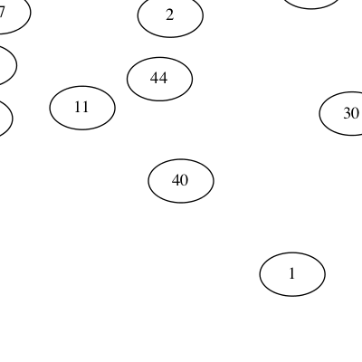

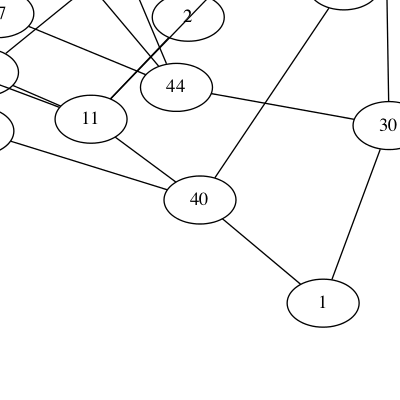

splines=none  
splines=""

splines=line  
splines=false

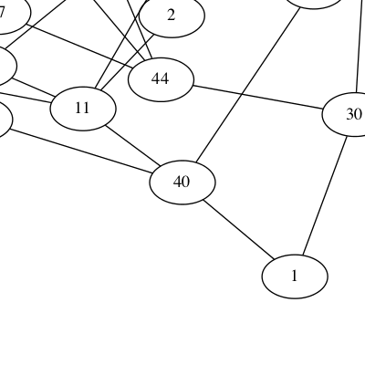

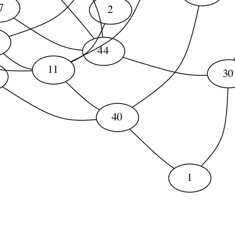

splines=polyline

splines=curved

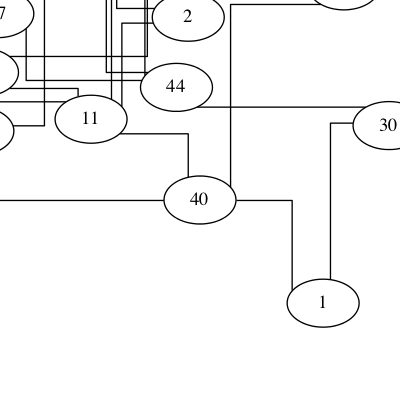

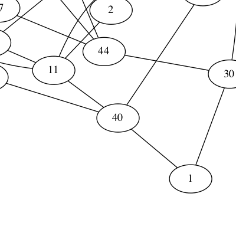

splines=ortho

splines=spline  
splines=true

By default, `splines` is unset. How this is interpreted depends on the layout engine. For `dot`, the default is to draw edges as splines. For all other layouts, the default is to draw edges as line segments.

Note that for these latter layouts, if `splines="true"`, this requires non-overlapping nodes (cf. `overlap`). If `fdp` is used for layout and `splines="compound"`, then the edges are drawn to avoid clusters as well as nodes.

*Valid on:*

- Graphs

### start

Parameter used to determine the initial layout of nodes

type: *startType, default: `""`*

If unset, the nodes are randomly placed in a unit square with the same seed is always used for the random number generator, so the initial placement is repeatable.

The following examples have the same graph, but render differently due to their `start` values:

Set random seed to 1

```
graph {
    layout="fdp"
    start=1
    A -- B; B -- C; C -- D; D -- A
}
```

[Edit in Playground](https://magjac.com/graphviz-visual-editor/?dot=graph%20%7b%0a%20%20%20%20layout%3d%22fdp%22%0a%20%20%20%20start%3d1%0a%20%20%20%20A%20--%20B%3b%20B%20--%20C%3b%20C%20--%20D%3b%20D%20--%20A%0a%7d)

Set random seed to 2, graph looks different

```
graph {
    layout="fdp"
    start=2
    A -- B; B -- C; C -- D; D -- A
}
```

[Edit in Playground](https://magjac.com/graphviz-visual-editor/?dot=graph%20%7b%0a%20%20%20%20layout%3d%22fdp%22%0a%20%20%20%20start%3d2%0a%20%20%20%20A%20--%20B%3b%20B%20--%20C%3b%20C%20--%20D%3b%20D%20--%20A%0a%7d)

*Valid on:*

- Graphs

*Note: neato, fdp, sfdp only.*

### style

Set style information for components of the graph

type: *style, default: `""`*

For cluster subgraphs, if `style="filled"`, the cluster box's background is filled.

If the default style attribute has been set for a component, an individual component can use `style=""` to revert to the normal default. For example, if the graph has

```
digraph {
  edge [style="invis"]
  a -> b
}
```

[Edit in Playground](https://magjac.com/graphviz-visual-editor/?dot=digraph%20%7b%0a%20%20edge%20%5bstyle%3d%22invis%22%5d%0a%20%20a%20-%3e%20b%0a%7d)

making all edges invisible, the `b->c` edge can override this via:

```
digraph {
  edge [style="invis"]
  a -> b
  b -> c [style=""]
}
```

[Edit in Playground](https://magjac.com/graphviz-visual-editor/?dot=digraph%20%7b%0a%20%20edge%20%5bstyle%3d%22invis%22%5d%0a%20%20a%20-%3e%20b%0a%20%20b%20-%3e%20c%20%5bstyle%3d%22%22%5d%0a%7d)

Of course, the component can also explicitly set its `style` attribute to the desired value.

*Valid on:*

- Edges
- Nodes
- Clusters
- Graphs

### stylesheet

A URL or pathname specifying an XML style sheet, used in SVG output

type: *string, default: `""`*

Combine with `class` to style elements using CSS selectors.

See also:

- `class`
- `id`

*Valid on:*

- Graphs

*Note: svg only.*

### tail_lp

Position of an edge's tail label, in points.

type: *point*

The position indicates the center of the label.

*Valid on:*

- Edges

*Note: write only.*

### tailclip

If true, the tail of an edge is clipped to the boundary of the tail node

type: *bool, default: `true`*

otherwise, the end of the edge goes to the center of the node, or the center of a port, if applicable.

*Valid on:*

- Edges

### tailhref

Synonym for `tailURL`.

type: *escString, default: `""`*

See also:

- `edgehref`, `edgeURL`
- `headhref`, `headURL`
- `labelhref`, `labelURL`
- `tailhref`, `tailURL`
- `href`, `URL`

*Valid on:*

- Edges

*Note: map, svg only.*

### taillabel

Text label to be placed near tail of edge

type: *lblString, default: `""`*

See limitation.

*Valid on:*

- Edges

### tailport

Indicates where on the tail node to attach the tail of the edge

type: *portPos, default: `center`*

See limitation.

*Valid on:*

- Edges

### tailtarget

Browser window to use for the `tailURL` link

type: *escString, default: `<none>`*

If the edge has a `tailURL`, `tailtarget` determines which window of the browser is used for the URL.

Setting `tailtarget=_graphviz` will open a new window if it doesn't already exist, or reuse it if it does.

If undefined, the value of the `target` is used.

*Valid on:*

- Edges

*Note: map, svg only.*

### tailtooltip

Tooltip annotation attached to the tail of an edge

type: *escString, default: `""`*

Used only if the edge has a `tailURL` attribute.

- `edgetooltip`.
- `headtooltip`.
- `labeltooltip`.
- `tooltip`.

*Valid on:*

- Edges

*Note: cmap, svg only.*

### tailURL

If defined, `tailURL` is output as part of the tail label of the edge

type: *escString, default: `""`*

Also, this value is used near the tail node, overriding any `URL` value.

See limitation.

See also:

- `edgehref`, `edgeURL`
- `headhref`, `headURL`
- `labelhref`, `labelURL`
- `tailhref`, `tailURL`
- `href`, `URL`

*Valid on:*

- Edges

*Note: map, svg only.*

### target

If the object has a `URL`, this attribute determines which window of the browser is used for the URL.

type: *escString | string, default: `<none>`*

See [W3C documentation](http://www.w3.org/TR/html401/present/frames.html#adef-target).

*Valid on:*

- Edges
- Nodes
- Graphs
- Clusters

*Note: map, svg only.*

### TBbalance

Which rank to move floating (loose) nodes to

type: *string, default: `''`*

Valid options:

- `"min"`: Move floating (loose) nodes to minimum `rank`.
- `"max"`: Move floating (loose) nodes to maximum `rank`.
- Otherwise, floating nodes are placed anywhere.

Despite the name `TBbalance` ("Top-Bottom Balance"), this also works with left-right ranks, e.g. `rankdir=LR`.

Examples:

Default Behaviour

```
digraph {
    layout="dot"

    { rank="min"; "min" }
    { rank="max"; "max" }
    "min" -> "middle" -> "max"

    "Floater 1"
    "Floater 2"
}
```

Edit in Playground

Floating nodes moved to min rank

```
digraph {
    layout="dot"
    TBbalance="min"

    { rank="min"; "min" }
    { rank="max"; "max" }
    "min" -> "middle" -> "max"

    "Floater 1"
    "Floater 2"
}
```

Edit in Playground

Floating nodes moved to max rank

```
digraph {
    layout="dot"
    TBbalance="max"

    { rank="min"; "min" }
    { rank="max"; "max" }
    "min" -> "middle" -> "max"

    "Floater 1"
    "Floater 2"
}
```

Edit in Playground

*Valid on:*

- Graphs

*Note: dot only.*

### tooltip

Tooltip (mouse hover text) attached to the node, edge, cluster, or graph

type: *escString, default: `""`*

If `tooltip` is unset, Graphviz will use the object's `label` if defined.

Note that if the `label` is a record specification or an HTML-like label, the resulting tooltip may be unhelpful. In this case, if tooltips will be generated, the user should set a `tooltip` attribute explicitly.

Tooltips

```
digraph {
  label="Graph Label"
  tooltip="Graph Tooltip"
  subgraph cluster_a {
    label="Cluster Label"
    tooltip="Cluster Tooltip"
    Node1 [tooltip="Node1 Tooltip"]
    Node1 -> Node2 [label="Edge" tooltip="Edge Tooltip"]
  }
}
```

Edit in Playground

See also:

- `edgetooltip`.
- `headtooltip`.
- `labeltooltip`.
- `tailtooltip`.

*Valid on:*

- Nodes
- Edges
- Clusters
- Graphs

*Note: cmap, svg only.*

### truecolor

Whether internal bitmap rendering relies on a truecolor color model or uses

type: *bool*

color palette.

If `truecolor` is unset, `truecolor` is not used unless there is a `shapefile` property for some node in the graph. The output model will use the input model when possible.

Use of color palettes results in less memory usage during creation of the bitmaps and smaller output files.

Usually, the only time it is necessary to specify the `truecolor` model is if the graph uses more than 256 colors. However, if one uses `bgcolor=transparent` with a color palette, font antialiasing can show up as a fuzzy white area around characters. Using `truecolor=true` avoids this problem.

*Valid on:*

- Graphs

*Note: bitmap output only.*

### URL

Hyperlinks incorporated into device-dependent output

type: *escString, default: `<none>`*

At present, used in `ps2`, `cmap`, `i*map` and `svg` formats. For all these formats, URLs can be attached to nodes, edges and clusters. URL attributes can also be attached to the root graph in `ps2`, `cmap` and `i*map` formats. This serves as the base URL for relative URLs in the former, and as the default image map file in the latter.

For `svg`, `cmapx` and `imap` output, the active area for a node is its visible image. For example, an unfilled node with no drawn boundary will only be active on its label. For other output, the active area is its bounding box. The active area for a cluster is its bounding box. For edges, the active areas are small circles where the edge contacts its head and tail nodes. In addition, for `svg`, `cmapx` and `imap`, the active area includes a thin polygon approximating the edge. The circles may overlap the related node, and the edge URL dominates. If the edge has a label, this will also be active. Finally, if the edge has a head or tail label, this will also be active.

For edges, the attributes `headURL`, `tailURL`, `labelURL` and `edgeURL` allow control of various parts of an edge.

if active areas of two edges overlap, it is unspecified which area dominates.

See also:

- `edgehref`, `edgeURL`
- `headhref`, `headURL`
- `labelhref`, `labelURL`
- `tailhref`, `tailURL`
- `href`, `URL`

Example: Van Gogh Paintings with Links

```
graph {
  label="Vincent van Gogh Paintings"
  URL="https://en.wikipedia.org/wiki/Vincent_van_Gogh"

  subgraph cluster_self_portraits {
    URL="https://en.wikipedia.org/wiki/Portraits_of_Vincent_van_Gogh"
    label="Self-portraits"

    "Self-Portrait with Grey Felt Hat" [URL="https://www.vangoghmuseum.nl/en/collection/s0016V1962"]
    "Self-Portrait as a Painter" [URL="https://www.vangoghmuseum.nl/en/collection/s0022V1962"]
  }

  subgraph cluster_flowers {
    URL="https://en.wikipedia.org/wiki/Sunflowers_(Van_Gogh_series)"
    label="Flowers"

    "Sunflowers" [URL="https://www.nationalgallery.org.uk/paintings/vincent-van-gogh-sunflowers"]
    "Almond Blossom" [URL="https://www.vangoghmuseum.nl/en/collection/s0176V1962"]
  }
}
```

Edit in Playground

*Valid on:*

- Edges
- Nodes
- Graphs
- Clusters

*Note: map, postscript, svg only.*

### vertices

Sets the coordinates of the vertices of the node's polygon, in inches

type: *pointList*

Used if the node is polygonal, and output is `dot` or `xdot`.

If the node is an ellipse or circle, the `samplepoints` attribute affects the output.

*Valid on:*

- Nodes

*Note: write only.*

### viewport

Clipping window on final drawing

type: *viewPort, default: `""`*

`viewport` supersedes any `size` attribute. The width and height of the viewport specify precisely the final size of the output.

*Valid on:*

- Graphs

### voro_margin

Tuning margin of Voronoi technique

type: *double, default: `0.05`, minimum: `0.0`*

Factor to scale up drawing to allow margin for expansion in [Voronoi technique](https://en.wikipedia.org/wiki/Voronoi_diagram). `dim' = (1+2*margin)*dim`.

*Valid on:*

- Graphs

*Note: neato, fdp, sfdp, twopi, circo only.*

### weight

Weight of edge

type: *int | double, default: `1`, minimum: `0(dot,twopi)`, `1(neato,fdp)`*

In `dot`, the heavier the weight, the shorter, straighter and more vertical the edge is.

For `twopi`, `weight=0` indicates the edge should not be used in constructing a spanning tree from the root.

For other layouts, a larger weight encourages the layout to make the edge length closer to that specified by the `len` attribute.

Weights in `dot` must be integers.

Edge Weights

```
digraph {
  root -> a
  root -> b [weight=2]
  root -> c [weight=3]
}
```

[Edit in Playground](https://magjac.com/graphviz-visual-editor/?dot=digraph%20%7b%0a%20%20root%20-%3e%20a%0a%20%20root%20-%3e%20b%20%5bweight%3d2%5d%0a%20%20root%20-%3e%20c%20%5bweight%3d3%5d%0a%7d)

*Valid on:*

- Edges

### width

Width of node, in inches

type: *double, default: `0.75`, minimum: `0.01`*

This is taken as the initial, minimum width of the node. If `fixedsize` is true, this will be the final width of the node. Otherwise, if the node label requires more width to fit, the node's width will be increased to contain the label.

If the output format is `dot`, the value given to `width` will be the final value.

If the node shape is regular, the width and height are made identical:

- If either the width or the height is set explicitly, that value is used.
- If both the width or the height are set explicitly, the maximum of the two values is used.
- If neither is set explicitly, the minimum of the two default values is used.

If a value below the minimum value (0.01) is set, it will be rounded up to this minimum.

Width Example

```
digraph {
  "d" # default
  "1in" [width=1]
  "2in" [width=2]
}
```

[Edit in Playground](https://magjac.com/graphviz-visual-editor/?dot=digraph%20%7b%0a%20%20%22d%22%20%23%20default%0a%20%20%221in%22%20%5bwidth%3d1%5d%0a%20%20%222in%22%20%5bwidth%3d2%5d%0a%7d)

*Valid on:*

- Nodes

### xdotversion

Determines the version of `xdot` used in output

type: *string*

Only used for `xdot` output.

If unset, graphviz will set this attribute to the `xdot` version used for output.

*Valid on:*

- Graphs

*Note: xdot only.*

### xlabel

External label for a node or edge

type: *lblString, default: `""`*

- For nodes, the label will be placed outside of the node but near it.
- For edges, the label will be placed near the center of the edge. This can be useful in dot to avoid the occasional problem when the use of edge labels distorts the layout.
- For other layouts, the xlabel attribute can be viewed as a synonym for the `label` attribute.

These labels are added after all nodes and edges have been placed.

The labels will be placed so that they do not overlap any node or label. This means it may not be possible to place all of them. To force placing all of them, set `forcelabels=true`.

External Labels on Nodes and Edges

```
digraph {
  "⚡" [xlabel="Sparks"]
  "🔥" [xlabel="Fires"]
  "⚡"->"🔥" [xlabel="Sometimes" label="Cause"]
}
```

Edit in Playground

*Valid on:*

- Edges
- Nodes

### xlp

Position of an exterior label, in points

type: *point*

The position indicates the center of the label.

*Valid on:*

- Nodes
- Edges

*Note: write only.*

### z

Z-coordinate value for 3D layouts and displays

type: *double, default: `0.0`*

**Deprecated:** Use `pos` attribute, along with `dimen` and/or `dim` to specify dimensions.

If the graph has `dim` set to 3 (or more), neato will use a node's `z` value for the z coordinate of its initial position if its `pos` attribute is also defined.

Even if no `z` values are specified in the input, it is necessary to declare a `z` attribute for nodes, e.g, using `node[z=""]` in order to get z values on output. Thus, setting `dim=3` but not declaring `z` will cause `neato -Tvrml` to layout the graph in 3D but project the layout onto the xy-plane for the rendering. If the `z` attribute is declared, the final rendering will be in 3D.

*Valid on:*

- Nodes

© 2025 The Graphviz Authors  
Licensed under the Eclipse Public License 1.0.  
https://www.graphviz.org/doc/info/attrs.html